# Examen minería datos II

Ricardo Alcañiz Frutos

09 de septiembre de 2019

## 1. Análisis gráfico y resumen de la información

## 1.1. Carga de los datos y estadísticas generales

Cargamos los datos y mostramos las primeras estadísticas básicas del dataset.

```r
suppressPackageStartupMessages(library(caret))
suppressPackageStartupMessages(library(tidyverse))
suppressPackageStartupMessages(library(data.table))
suppressPackageStartupMessages(library(lda))
suppressPackageStartupMessages(library(ggpubr))
suppressPackageStartupMessages(library(doParallel))
suppressPackageStartupMessages(library(dummies))
suppressPackageStartupMessages(library(MASS))
suppressPackageStartupMessages(library(Boruta))
suppressPackageStartupMessages(library(sampling))
suppressPackageStartupMessages(library(corrplot))
suppressPackageStartupMessages(library(ROCR))
suppressPackageStartupMessages(library(pROC))
suppressPackageStartupMessages(library(e1071))
suppressPackageStartupMessages(library(DMwR))
suppressPackageStartupMessages(library(genalg))
suppressPackageStartupMessages(library( bnclassify))
suppressPackageStartupMessages(library(mboost))
suppressPackageStartupMessages(library( caTools))
suppressPackageStartupMessages(library( mboost))
suppressPackageStartupMessages(library( xgboost))


credit_fraud_data <- read.csv("C:/Users/ricar/OneDrive/Escritorio/Práctica Minería de Datos II/creditcard.csv")

credit_fraud_data_dt <- as.data.table(credit_fraud_data)

credit_fraud_data_dt$Class <- as.factor(credit_fraud_data_dt$Class)

str(credit_fraud_data_dt)
```

```
## Classes 'data.table' and 'data.frame':   284807 obs. of  31 variables:
##  $ Time  : num  0 0 1 1 2 2 4 7 7 9 ...
##  $ V1    : num  -1.36 1.192 -1.358 -0.966 -1.158 ...
##  $ V2    : num  -0.0728 0.2662 -1.3402 -0.1852 0.8777 ...
##  $ V3    : num  2.536 0.166 1.773 1.793 1.549 ...
##  $ V4    : num  1.378 0.448 0.38 -0.863 0.403 ...
##  $ V5    : num  -0.3383 0.06 -0.5032 -0.0103 -0.4072 ...
##  $ V6    : num  0.4624 -0.0824 1.8005 1.2472 0.0959 ...
##  $ V7    : num  0.2396 -0.0788 0.7915 0.2376 0.5929 ...
##  $ V8    : num  0.0987 0.0851 0.2477 0.3774 -0.2705 ...
##  $ V9    : num  0.364 -0.255 -1.515 -1.387 0.818 ...
##  $ V10   : num  0.0908 -0.167 0.2076 -0.055 0.7531 ...
##  $ V11   : num  -0.552 1.613 0.625 -0.226 -0.823 ...
##  $ V12   : num  -0.6178 1.0652 0.0661 0.1782 0.5382 ...
##  $ V13   : num  -0.991 0.489 0.717 0.508 1.346 ...
```

[output cut: 18 more lines]

```r
summary(credit_fraud_data_dt)
```

```
##       Time              V1                  V2
##  Min.   :     0   Min.   :-56.40751   Min.   :-72.71573
##  1st Qu.: 54202   1st Qu.: -0.92037   1st Qu.: -0.59855
##  Median : 84692   Median :  0.01811   Median :  0.06549
##  Mean   : 94814   Mean   :  0.00000   Mean   :  0.00000
##  3rd Qu.:139321   3rd Qu.:  1.31564   3rd Qu.:  0.80372
##  Max.   :172792   Max.   :  2.45493   Max.   : 22.05773
##        V3                 V4                 V5
##  Min.   :-48.3256   Min.   :-5.68317   Min.   :-113.74331
##  1st Qu.: -0.8904   1st Qu.:-0.84864   1st Qu.:  -0.69160
##  Median :  0.1799   Median :-0.01985   Median :  -0.05434
##  Mean   :  0.0000   Mean   : 0.00000   Mean   :   0.00000
##  3rd Qu.:  1.0272   3rd Qu.: 0.74334   3rd Qu.:   0.61193
##  Max.   :  9.3826   Max.   :16.87534   Max.   :  34.80167
##        V6                 V7                 V8
##  Min.   :-26.1605   Min.   :-43.5572   Min.   :-73.21672
##  1st Qu.: -0.7683   1st Qu.: -0.5541   1st Qu.: -0.20863
##  Median : -0.2742   Median :  0.0401   Median :  0.02236
##  Mean   :  0.0000   Mean   :  0.0000   Mean   :  0.00000
##  3rd Qu.:  0.3986   3rd Qu.:  0.5704   3rd Qu.:  0.32735
##  Max.   : 73.3016   Max.   :120.5895   Max.   : 20.00721
##        V9                 V10                 V11
##  Min.   :-13.43407   Min.   :-24.58826   Min.   :-4.79747
##  1st Qu.: -0.64310   1st Qu.: -0.53543   1st Qu.:-0.76249
##  Median : -0.05143   Median : -0.09292   Median :-0.03276
##  Mean   :  0.00000   Mean   :  0.00000   Mean   : 0.00000
##  3rd Qu.:  0.59714   3rd Qu.:  0.45392   3rd Qu.: 0.73959
##  Max.   : 15.59500   Max.   : 23.74514   Max.   :12.01891
##       V12                V13                V14
##  Min.   :-18.6837   Min.   :-5.79188   Min.   :-19.2143
##  1st Qu.: -0.4056   1st Qu.:-0.64854   1st Qu.: -0.4256
##  Median :  0.1400   Median :-0.01357   Median :  0.0506
##  Mean   :  0.0000   Mean   : 0.00000   Mean   :  0.0000
##  3rd Qu.:  0.6182   3rd Qu.: 0.66251   3rd Qu.:  0.4931
##  Max.   :  7.8484   Max.   : 7.12688   Max.   : 10.5268
##       V15                V16                 V17
##  Min.   :-4.49894   Min.   :-14.12985   Min.   :-25.16280
##  1st Qu.:-0.58288   1st Qu.: -0.46804   1st Qu.: -0.48375
##  Median : 0.04807   Median :  0.06641   Median : -0.06568
##  Mean   : 0.00000   Mean   :  0.00000   Mean   :  0.00000
```

[output cut: 15 more lines]

```
##  Max.   : 27.20284   Max.   : 10.503090   Max.   : 22.52841
##       V24                V25                 V26
##  Min.   :-2.83663   Min.   :-10.29540   Min.   :-2.60455
##  1st Qu.:-0.35459   1st Qu.: -0.31715   1st Qu.:-0.32698
##  Median : 0.04098   Median :  0.01659   Median :-0.05214
##  Mean   : 0.00000   Mean   :  0.00000   Mean   : 0.00000
##  3rd Qu.: 0.43953   3rd Qu.:  0.35072   3rd Qu.: 0.24095
##  Max.   : 4.58455   Max.   :  7.51959   Max.   : 3.51735
##       V27                  V28                Amount         Class
##  Min.   :-22.565679   Min.   :-15.43008   Min.   :    0.00   0:284315
##  1st Qu.: -0.070840   1st Qu.: -0.05296   1st Qu.:    5.60   1:   492
##  Median :  0.001342   Median :  0.01124   Median :   22.00
##  Mean   :  0.000000   Mean   :  0.00000   Mean   :   88.35
##  3rd Qu.:  0.091045   3rd Qu.:  0.07828   3rd Qu.:   77.17
##  Max.   : 31.612198   Max.   : 33.84781   Max.   :25691.16
```

```r
dim(credit_fraud_data_dt)
```

```
## [1] 284807     31
```

## 1.2. Resúmen de la información y análisis gráfico por variable

La siguiente función discretiza una variable continua dada como parámetro (variable), diviendo la variable en tantos intervalos como se especifique en el parámetro (n_intervalos), y realiza un resumen tanto a nivel numérico como gráfico de la influencia de cada intervalo de valores en la discrimización de la variable respuesta. Para ello se ha creado un dataset con una fila por cada fila del dataset credit_fraud_data_dt con lo siguientes campos:

- interval: con el parámetro n_intervalos se fijan el número de intervalos de igual longitud en los que se divide la variable dada como parámetro. Pues bien, ‘interval’ denota, para cada valor de la variable, el extremo inferior del intervalo al que pertenece.
- Class: el valor de la variable respuesta (0,1)
- factor: variable descriptiva del factor. Se trata de una cadena formada por el valor de los extremo inferior y superior del intervalo, separada por una coma.

Con estos datos construímos las siguientes totalizaciones:

- Por cada intervalo (variable factor), el número de casos de fraude
- Por cada intervalo, el número total de casos
- Calcular el procentaje de casos de fraude entre el total por intervalo, creando una métrica normalizada que no de más valor a los casos mayoritarios
- Finalmente mostrar una tabla resumen y un gráfico ordenado por intervalo

Como apunte adicional, el argumento mediante el cual se deduce el intervalo al que pertenece un valor x concreto de una variable es el siguiente:

sean a y b los extremos de la partición y sea i el valor que cumpla a + (b-a)/n * i <= x < a + (b-a)/n * (i+1) (basta tomar i como el máximo del conjunto {i: a + (b-a)/n * i <= x}). Entonces, claramente i es el extremo inferior al que pertenece x. Con una manipulación sencilla se llega a la desigualdad i <= ((x-a)/(b-a)) * n < i+1. Esto es i es la parte entera de ((x-a)/(b-a)) * n.

```r
#Params:
# variable: nombre de la variable continua del dataset
#n_intervalos: número de intervalos equiespaciados en los que discretizar la variable continua
plot_influence_variable_in_fraud <- function(variable, n_intervalos) {

  #Creamos un dataset vacío
  dt <- data.table()
  cols <- c(variable)
  #Acceso a la variable del dataset por nombre
  dt[, value := credit_fraud_data_dt[, mget(cols)]]
  # Calculamos el valor máximo y mínimo de la variable
  a <- min(dt$value)
  b <- max(dt$value)
  # Calculamos el extremo inferior del intervalo al que pertenece el valor
  dt[, interval := floor(((dt$value-a) / (b-a)) * n_intervalos)]
  # Añadimos la clase del dataset original
  dt[, class := credit_fraud_data_dt[, mget(c("Class"))]]
  # Calculamos el factor
  dt[, factor := paste( round(a + ( ((b-a) / n_intervalos) * dt$interval), 2), round(a + ( ((b-a) / n_intervalos) * (dt$interval + 1)), 2),   sep=",")]

 # Cálculos con la información resumida por factores y muestra de los datos (tablas y gráficas)
 fraud_yes <- dt[, . (cnt = .N), by = list(factor, class, interval)][class == 1]
 cnt_by_class <- dt[, .(cnt = .N), by = list(factor, interval)]
 fraud_resume <- fraud_yes[cnt_by_class, on="factor", nomatch=0][, .(factor, cnt, i.cnt, interval)]
 fraud_resume$porcentaje <- fraud_resume$cnt / fraud_resume$i.cnt
 #fraud_resume <- fraud_resume[order(interval)]
 names(fraud_resume) <- c("factor", "fraude_si", "total", "interval", "porcentaje")
 print(paste("Tabla resumen para la vaiable ", variable))
 print(fraud_resume[order(interval)][, .(factor, fraude_si, total, porcentaje)])
 p <- ggplot(data=as.data.frame(fraud_resume), aes(x=reorder(factor, interval), y=porcentaje)) +
      ggtitle(paste("Gráfico para la variable ", variable)) +
      geom_bar(stat="identity", fill="#56B4E9") +
      theme_minimal()
 plot(p)
}
```

Finalmente, invocamos la función para cada una de las variables y un número de diez intervalos. En caso de que algún intervalo no tenga casos de fraude no aparecerá (no sirve como factor discriminativo claramente).

```
## [1] "Tabla resumen para la vaiable  Time"
##                factor fraude_si total   porcentaje
##  1:         0,17279.2        42 10510 0.0039961941
##  2:   17279.2,34558.4        48 16955 0.0028310233
##  3:   34558.4,51837.6        79 38526 0.0020505633
##  4:   51837.6,69116.8        63 38550 0.0016342412
##  5:     69116.8,86396        49 40243 0.0012176031
##  6:    86396,103675.2        68 10145 0.0067028093
##  7: 103675.2,120954.4        11 17161 0.0006409883
##  8: 120954.4,138233.6        34 38951 0.0008728916
##  9: 138233.6,155512.8        66 40779 0.0016184801
## 10:   155512.8,172792        32 32986 0.0009701085
```

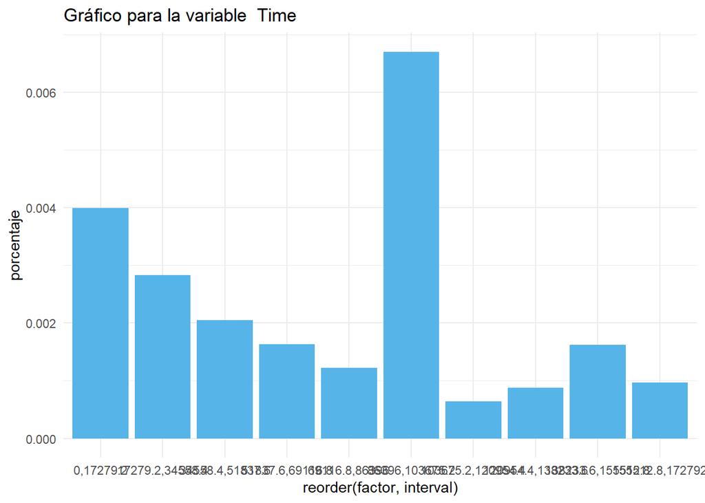

```
## [1] "Tabla resumen para la vaiable  V1"
##           factor fraude_si  total  porcentaje
## 1: -32.86,-26.98         8     30 0.266666667
## 2: -26.98,-21.09        15     81 0.185185185
## 3:  -21.09,-15.2        23    184 0.125000000
## 4:   -15.2,-9.32        41    889 0.046119235
## 5:   -9.32,-3.43       114   9462 0.012048193
## 6:    -3.43,2.45       291 274137 0.001061513
```

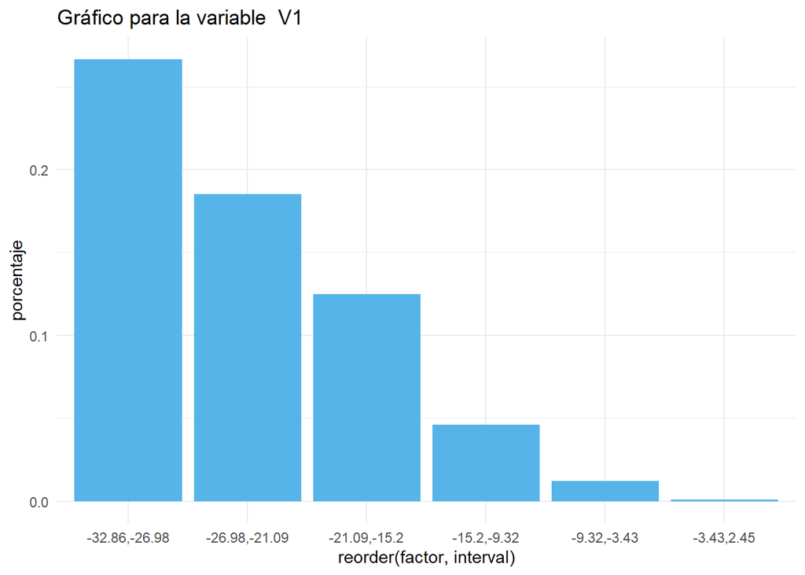

```
## [1] "Tabla resumen para la vaiable  V2"
##          factor fraude_si  total   porcentaje
## 1: -15.85,-6.37         5   1463 0.0034176350
## 2:    -6.37,3.1       269 278631 0.0009654346
## 3:    3.1,12.58       187   4427 0.0422407951
## 4:  12.58,22.06        30     37 0.8108108108
## 5:  22.06,31.54         1      1 1.0000000000
```

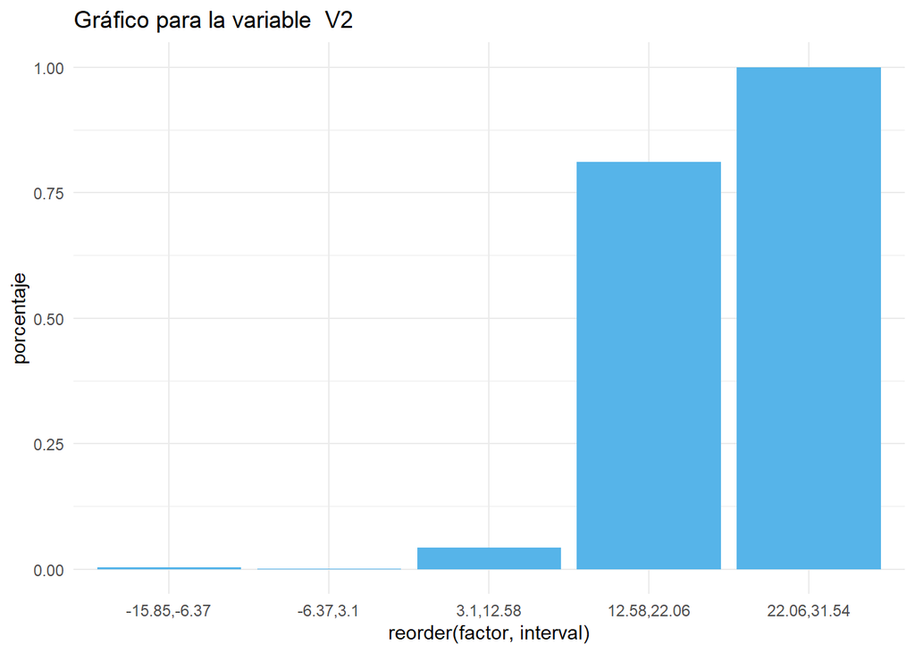

```
## [1] "Tabla resumen para la vaiable  V3"
##           factor fraude_si  total   porcentaje
## 1: -36.78,-31.01         1      5 0.2000000000
## 2: -31.01,-25.24        16     17 0.9411764706
## 3: -25.24,-19.47        29     38 0.7631578947
## 4:  -19.47,-13.7        28     68 0.4117647059
## 5:   -13.7,-7.93        60    350 0.1714285714
## 6:   -7.93,-2.16       240  18185 0.0131976904
## 7:    -2.16,3.61       118 266017 0.0004435807
```

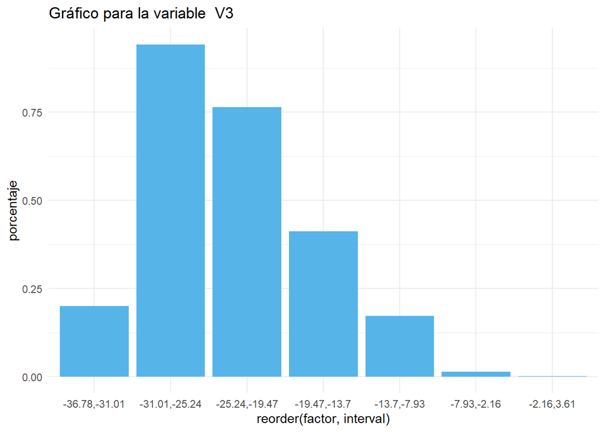

```
## [1] "Tabla resumen para la vaiable  V4"
##         factor fraude_si  total   porcentaje
## 1: -3.43,-1.17         2  50190 3.984858e-05
## 2:  -1.17,1.08        47 182030 2.581992e-04
## 3:   1.08,3.34       144  43107 3.340525e-03
## 4:    3.34,5.6       131   7501 1.746434e-02
## 5:    5.6,7.85       104    319 3.260188e-01
## 6:  7.85,10.11        38     83 4.578313e-01
## 7: 10.11,12.36        26     45 5.777778e-01
```

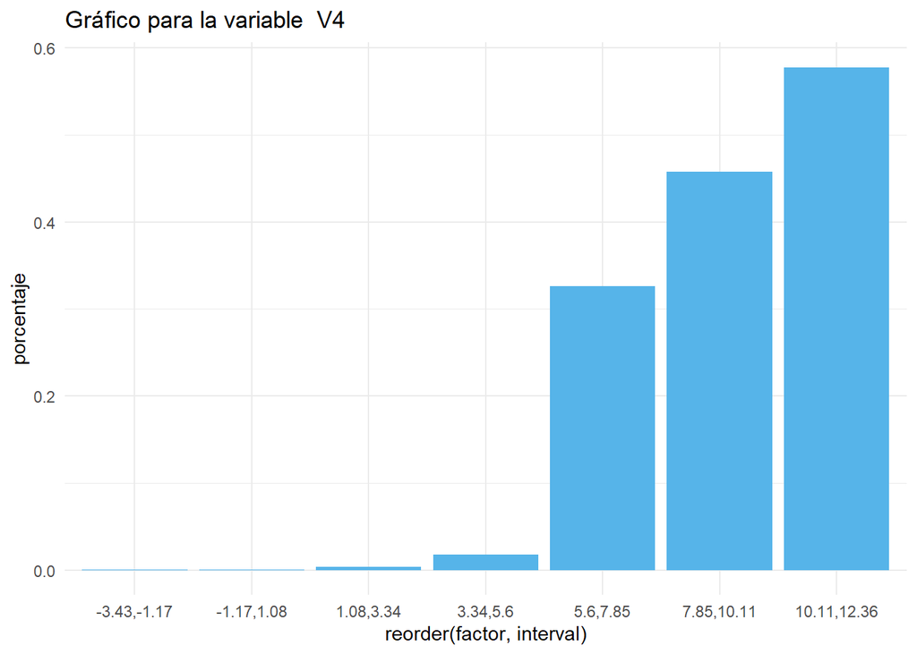

```
## [1] "Tabla resumen para la vaiable  V5"
##          factor fraude_si  total porcentaje
## 1: -24.62,-9.76        68    252 0.26984127
## 2:   -9.76,5.09       419 283733 0.00147674
## 3:   5.09,19.95         5    787 0.00635324
```

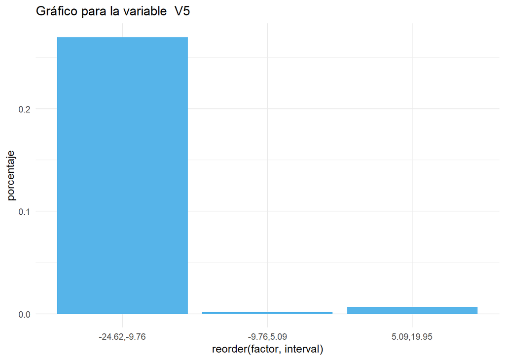

```
## [1] "Tabla resumen para la vaiable  V6"
##          factor fraude_si  total  porcentaje
## 1: -16.21,-6.27         1    171 0.005847953
## 2:   -6.27,3.68       481 277728 0.001731910
## 3:   3.68,13.62        10   6871 0.001455392
```

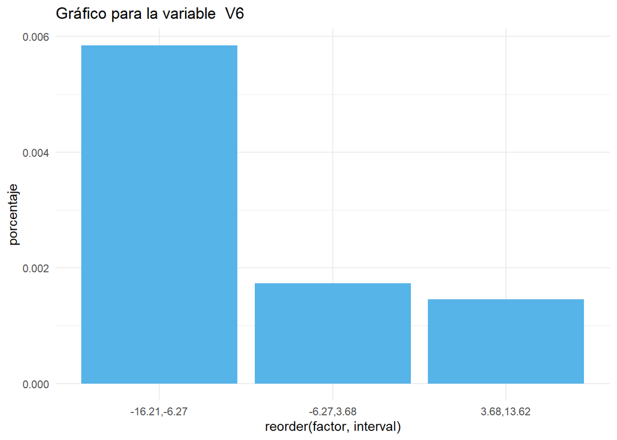

```
## [1] "Tabla resumen para la vaiable  V7"
##           factor fraude_si  total  porcentaje
## 1: -43.56,-27.14        10     11 0.909090909
## 2: -27.14,-10.73        87    205 0.424390244
## 3:   -10.73,5.69       394 284016 0.001387246
## 4:     5.69,22.1         1    551 0.001814882
```

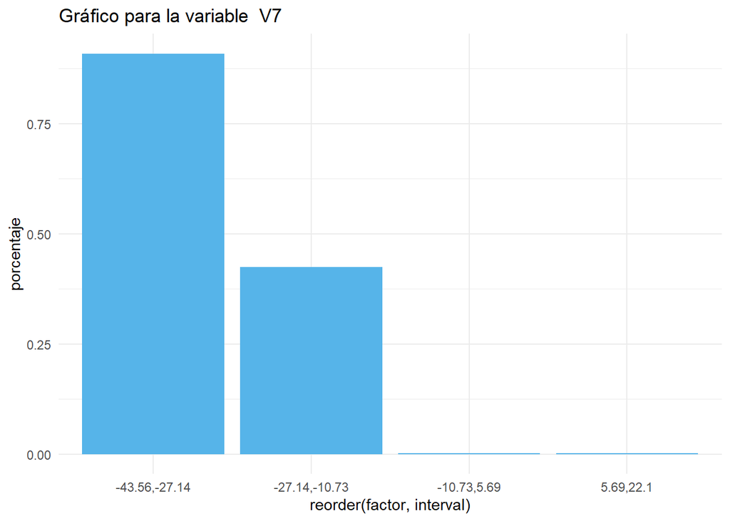

```
## [1] "Tabla resumen para la vaiable  V8"
##           factor fraude_si  total  porcentaje
## 1: -45.25,-35.93         8     12 0.666666667
## 2:  -35.93,-26.6         1     12 0.083333333
## 3:  -26.6,-17.28         1    109 0.009174312
## 4:  -17.28,-7.96        11    766 0.014360313
## 5:    -7.96,1.36       317 276426 0.001146781
## 6:    1.36,10.68       134   7443 0.018003493
## 7:   10.68,20.01        19     34 0.558823529
## 8:   20.01,29.33         1      1 1.000000000
```

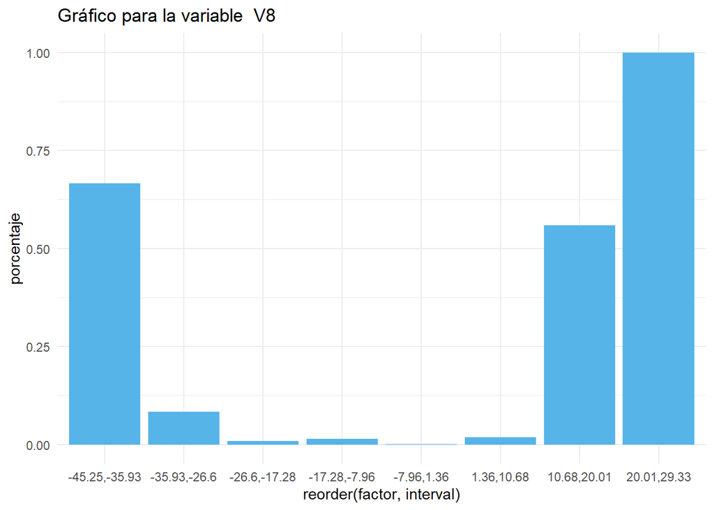

```
## [1] "Tabla resumen para la vaiable  V9"
##           factor fraude_si  total   porcentaje
## 1: -13.43,-10.53         4      4 1.0000000000
## 2:  -10.53,-7.63        19     19 1.0000000000
## 3:   -7.63,-4.73        54     60 0.9000000000
## 4:   -4.73,-1.82       197  12713 0.0154959490
## 5:    -1.82,1.08       205 232671 0.0008810724
## 6:     1.08,3.98        13  38163 0.0003406441
```

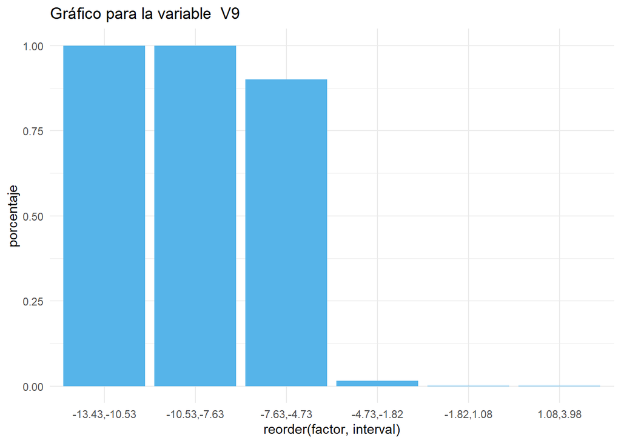

```
## [1] "Tabla resumen para la vaiable  V10"
##           factor fraude_si  total   porcentaje
## 1: -24.59,-19.75         9      9 1.0000000000
## 2: -19.75,-14.92        18     18 1.0000000000
## 3: -14.92,-10.09        59     77 0.7662337662
## 4:  -10.09,-5.25       117    177 0.6610169492
## 5:   -5.25,-0.42       234  85797 0.0027273681
## 6:    -0.42,4.41        55 196980 0.0002792162
```

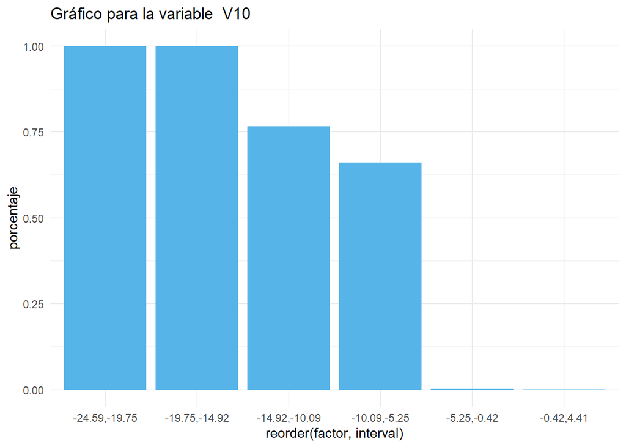

```
## [1] "Tabla resumen para la vaiable  V11"
##          factor fraude_si  total   porcentaje
##  1: -3.12,-1.43         5  20315 0.0002461236
##  2:  -1.43,0.25        35 148592 0.0002355443
##  3:   0.25,1.93        79 109621 0.0007206648
##  4:   1.93,3.61       130   5859 0.0221880867
##  5:   3.61,5.29       119    181 0.6574585635
##  6:   5.29,6.97        59     64 0.9218750000
##  7:   6.97,8.66        37     47 0.7872340426
##  8:  8.66,10.34        18     29 0.6206896552
##  9: 10.34,12.02         9      9 1.0000000000
## 10:  12.02,13.7         1      1 1.0000000000
```

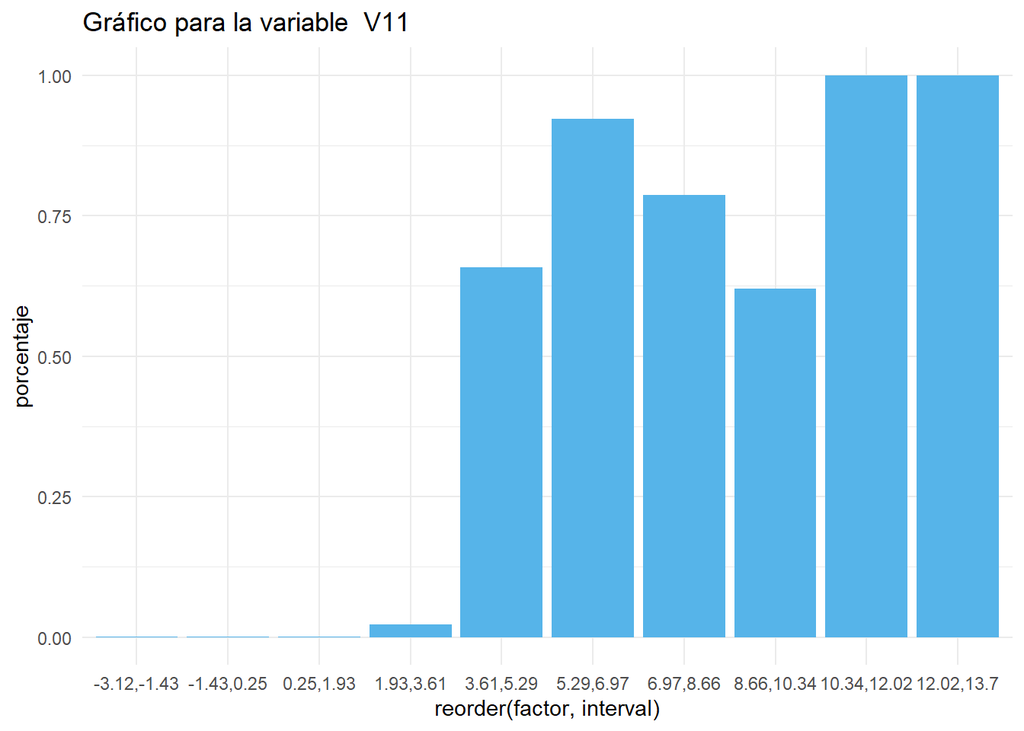

```
## [1] "Tabla resumen para la vaiable  V12"
##           factor fraude_si  total   porcentaje
## 1: -18.68,-16.03        21     21 1.0000000000
## 2: -16.03,-13.38        36     47 0.7659574468
## 3: -13.38,-10.72        25     35 0.7142857143
## 4:  -10.72,-8.07        64     69 0.9275362319
## 5:   -8.07,-5.42       105    127 0.8267716535
## 6:   -5.42,-2.76       129   4606 0.0280069475
## 7:   -2.76,-0.11        81 100696 0.0008044014
## 8:    -0.11,2.54        31 178826 0.0001733529
```

[18 more figures not shown]

```r
n_interval <- 10
for(variable in c("Time", "V1", "V2", "V3", "V4", "V5", "V6", "V7", "V8", "V9", "V10", "V11", "V12", "V13", "V14", "V15", "V16", "V17", "V18",
                  "V19", "V20", "V21", "V22", "V23", "V24", "V25", "V26", "V27", "V28", "Amount")) {
  plot_influence_variable_in_fraud(variable, n_interval)
}
```

## 1.3. Estudio gráfico de la separabildiad de las variables

A continuación, realizamos un estudio gráfico de la separabilidad lineal de las variables. Es decir, se estudia, desde un punto de vista intuitivo, si existe alguna transformación lineal capaz de establecer una separación en las clases. Primeramente, hacemos uso de la libreria caret para ver la separabilidad a través de las distintas componentes principales.

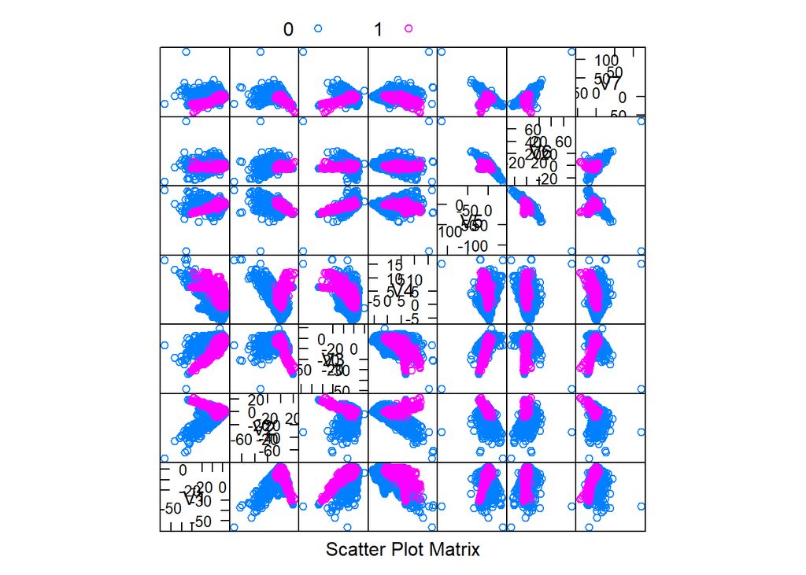

```r
featurePlot(x = credit_fraud_data_dt[, .(V1, V2, V3, V4, V5, V6, V7)],
            y = credit_fraud_data_dt$Class,
            plot = "pairs",
            auto.key = list(columns = 3))
```

## 1.4. Estudio de la separabildiad mediante LDA

Igualmente, probamos a realizar la separación mediante LDA a través de la representación gráfica de la distribución para cada clase.

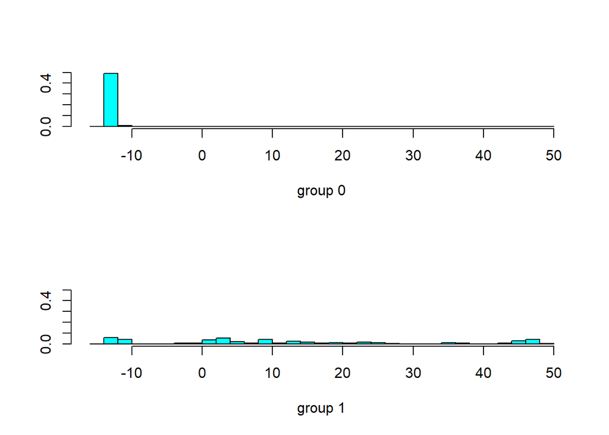

```r
lda <- lda(Class ~ .,
           data=credit_fraud_data_dt)


plot(lda, panel = panel.lda, cex = 0.7, dimen = 1, abbrev = FALSE, type ="histogram")
```

## 2. Preprocesado de los datos

## 2.1. Estudio e imputación de los valores faltantes

Como puede observarse, no existen valores faltantes, por lo que no es necesario llevar a cabo acción alguna.

```r
n_valores_faltantes <- nrow(na.omit(credit_fraud_data_dt, invert=TRUE))
total_valores <- nrow(credit_fraud_data_dt)
n_valores_faltantes
```

```
## [1] 0
```

## 2.2. Transformación de las variables continuas sesgadas y normalización de variables

Realizamos las operaciones básicas para normalizar variables y eliminar el sesgo de las mismas.

```r
normalization <- preProcess(credit_fraud_data_dt,method = c("BoxCox", "center", "scale"))
credit_fraud_data_normalized_dt <- predict(normalization, credit_fraud_data_dt)
```

## 2.3. Eliminación de valores atípicos y predictores variablidad casi nula

La definición de los valores atípicos y de los predictores de variabilidad casi nula no es puramente técnica, sino que debe complementarse con una compresión de las variables. Valores atípicos pueden denotar un error en los datos o circunstancias anormales, reales y perfectamente posibles de un proceso de negocio. Igualmente, predictores de variabilidad casi nula pueden indicar igualmente valores raros, pero reales y perfectamente válidos dentro del proceso de negocio. Por tanto, la decisión es no llevar a cabo ninguna de estas transformaciones sin tener las variables originales, ya que podríamos estar deteriorando e incluso anulando la capacidad predictiva de nuestro dataset.

## 2.4. Selección de variables mediante algoritmos genéticos

Se hará uso de la librería genalg de R para la selección de algoritmos genéticos junto con la librería rpart. Sin embargo, usaremos esta última de manera indirecta, usando la librería caret como interfaz, ya que es mucho más cómoda y general. Con el uso de genalg, la implementación de los algoritmos genéticos se reduce a configurar los parámetros del algoritmo y a la creación de la función de fitness. Comentamos los pasos seguidos para la creación de la misma:

- Transformación de la variable respueta 0-1 en una variable descriptiva yes-no, con el fin de que tenga compatibilidad con la librería rpart
- Creamos los conjuntos de entrenamiento y validación, que se usarán para el entrenamiento del algoritmo CART

A continuación, se crea la función que será usada para medir el fitness de los individuos. Se describen los pasos implementados y las decisiones tomadas:

```r
# Construcción de la función de evaluación

set.seed(123)

# Transformación de la variable respuesta de numérica a string para algoritmo rpart
credit_fraud_data_normalized_dt[, y := ifelse(Class == 1,"Yes","No")]
credit_fraud_data_normalized_dt$y <- as.factor(credit_fraud_data_normalized_dt$y)
credit_fraud_data_normalized_dt$Class <- NULL


fiveStats = function(...) c (twoClassSummary(...), defaultSummary(...))
train.control <- trainControl(method = "repeatedcv", number = 10, repeats = 5, classProbs = TRUE, summaryFunction = fiveStats)

# Creamos el conjunto de datos de entrenamiento y test
train.index <- createDataPartition(y = credit_fraud_data_normalized_dt$y, p= 0.8, list = FALSE)
data.training <- credit_fraud_data_normalized_dt[train.index,]
data.testing <- credit_fraud_data_normalized_dt[-train.index,]

cartGrid <-  expand.grid(cp = (0:10)/100)

#Params:
#chromosome: vector de 0-1s indicando la presencia-ausencia de la varible
fitt_function <- function(chromosome) {

  # Desechamos los conjuntos de variables que no tengan exactamente 7 variables
  if(length(which(chromosome==1)) != 7)
    return(0)

  # Se añade la variable respuesta al dataset
  selected_variables <- c(chromosome, 1)


  # Seleccionamos las varibales con gen activo en el cromosoma
  training_data <- data.training[, selected_variables==1, with=FALSE]
  test_data <- data.testing[, selected_variables==1, with=FALSE]

   # Entrenamiento del algoritmo
  clusterCPU <- registerDoParallel(cores=detectCores() - 1)
  CART_tree <- train(y ~., data = training_data,
                     method = "rpart",
                     #parms = list(split = "information"),
                     preProc = c("center", "scale"),
                     trControl = train.control,
                     metric = "ROC",
                     tuneGrid = cartGrid)
  stopImplicitCluster()

  # Cálculo de la métrica ROC
  roc_value <- auc(roc(test_data$y,predict(CART_tree, test_data, type="prob")[,"Yes"]))

  # Se devuelve el negativo de la curva ROC
  return(-roc_value[1])

}
```

A continuación, entrenamos el algoritmo con sólo quince etapas, habiendo tardado casi un total de veinticuatro horas en proporcionar la salida. Se muestran las variables seleccionadas por el algoritmo junto con la métrica ROC obtenida y se crea un nuevo dataset con las variables seleccionadas.

```r
#iter <- 15
#selected_variables <- rbga.bin(size = 30, popSize = 40, iters = iter, mutationChance = 0.01, evalFunc = fitt_function, verbose = TRUE)
#saveRDS(selected_variables, file = "GAmodel.rds")


model.GA <- readRDS(file = "GAmodel.rds")

summary(model.GA, echo=TRUE)
```

```
## GA Settings
##   Type                  = binary chromosome
##   Population size       = 40
##   Number of Generations = 15
##   Elitism               = 8
##   Mutation Chance       = 0.01
##
## Search Domain
##   Var 1 = [,]
##   Var 0 = [,]
##
## GA Results
##   Best Solution : 0 1 1 0 0 0 0 0 1 0 0 0 0 0 0 0 1 0 0 0 0 0 1 0 0 1 1 0 0 0
```

```r
print("Area bajo la curva ROC de la mejor solución obtenida:")
```

```
## [1] "Area bajo la curva ROC de la mejor solución obtenida:"
```

```r
-model.GA$best[15]
```

```
## [1] 0.9138584
```

```r
variables_best_solution <- c(0, 1, 1, 0, 0, 0, 0, 0, 1, 0, 0, 0, 0, 0, 0, 0, 1, 0, 0, 0, 0, 0, 1, 0, 0, 1, 1, 0, 0, 0, 1)

credit_fraud_proyection_dt <- credit_fraud_data_normalized_dt[, variables_best_solution==1, with=FALSE]
```

## 2.5. Balanceo de la muestra

Claramente, existe un desbalanceo entre las clases. Para resolver este punto, vamos a aplicar la técnica SMOTE para sobremuestrear la clase minoritaria y el método del cubo para obtener un submeestreo equilibrado de la clase mayoritaria, cumpliendo así con las especificaciones técnicas en el examen.

## 2.5.1. Submestreo balanceado mediante el método del cubo

```r
datos_no <- subset(credit_fraud_proyection_dt, credit_fraud_proyection_dt$y == "No")

nA <- nrow(datos_no)
nB <- 600

UNO=rep(1,dim(datos_no)[1])

pik = rep(nB/nA, nA)

X <- cbind(UNO, dim(datos_no[, names(datos_no) != "y", with=FALSE])[1])


s=samplecube(as.matrix(X), pik, method=1, order = 1)
```

```
##
## BEGINNING OF THE FLIGHT PHASE
## The matrix of balanced variable has 2  variables and  284315  units
## The size of the inclusion probability vector is  284315
## The sum of the inclusion probability vector is  600
## The inclusion probability vector has  284315  non-integer elements
## Step 1  Step  2 ,
##
## NO LANDING PHASE
##
## QUALITY OF BALANCING
##          TOTALS HorvitzThompson_estimators Relative_deviation
## UNO      284315                     284315       1.412633e-12
## 2   80835019225                80835019225       7.928113e-13
```

```r
muestra = cbind(datos_no,s)
subbalanced_data <- muestra[muestra$s == 1,]
subbalanced_data$s  <- NULL
```

## 2.5.2. Sobremuestreo de la clase minoritaria mediante el método SMOTE

```r
balanced_yes_class <- SMOTE(y ~ ., credit_fraud_proyection_dt, perc.over = 22)

balanced_yes_class <- balanced_yes_class[y == "Yes"]

balanced_data <- rbind(subbalanced_data,balanced_yes_class)
```

## 2.5.3. Obtención de las muestras de validación y test

A partir de la muestra de datos generada en los apartados anteriores se van a generar dos muestras:

```
 - Una para entrenar las redes bayesianas, lo cual exige la discretización de las variables
 - Una con los datos sin discretizar, por tanto, usando las variables numéricas para el entrenamiento de los restantes algoritmos
```

## 2.5.3.1. Creación de datos de entreamiento y test con variables discretizadas

Existen muchas técnicas de discretización de variables, pero nosotros vamos a usar la función proporcionada por los profesores en el documento de preprocesado de datos para obtener una discretización de las variables. Como veremos en la sección de entrenamiento de los algoritmos, esto será suficiente para obtener una buenos predictores.

```r
# Función para crear intervalos de las variables explicativas
# Argumentos: variable y número de niveles a crear
factorizarVariable <- function( variable, cortes ){
  resultado <- NULL
  breaks <- NULL
  levels <- NULL
  etiquetas <- NULL

  for ( i in 0:cortes ){
    if ( i == 0 ) breaks <- min( variable ) - 1
    else if ( i < cortes ){
      quantil = i / cortes
      breaks <- c( breaks, quantile(variable, quantil) )
    }
    else if ( i == cortes ) breaks <- c( breaks, max( variable ) + 1 ) }

  for ( j in 1:cortes ){
    if ( j == 1 ){
      quantil = 1 / cortes
      etiquetas <- paste( "Menos de", quantile(variable, quantil) )
    } else if ( j < cortes ){
        quantila = ( j - 1 ) / cortes
        quantilb = j / cortes
        etiquetas <- c( etiquetas, paste("De", quantile( variable, quantila ), "a", quantile( variable, quantilb ) ) )
    } else if ( j == cortes ){
          quantil = ( j - 1 ) / cortes
          etiquetas <- c( etiquetas, paste( "Más de", quantile(variable, quantil) ) )
    }
  }

  for ( k in 1:cortes ) levels <- c( levels, k )

  resultado <- cut( variable, breaks = breaks, labels = etiquetas, levels = levels )
  return ( resultado )
}
```

Creamos el dataset con las variables discretizadas:

```r
balanced_data.d <- data.table()
balanced_data.d$V1 <- factorizarVariable(balanced_data$V1, 5)
balanced_data.d$V2 <- factorizarVariable(balanced_data$V2, 5)
balanced_data.d$V8 <- factorizarVariable(balanced_data$V8, 5)
balanced_data.d$V16 <- factorizarVariable(balanced_data$V16, 5)
balanced_data.d$V22 <- factorizarVariable(balanced_data$V22, 5)
balanced_data.d$V25 <- factorizarVariable(balanced_data$V25, 5)
balanced_data.d$V26 <- factorizarVariable(balanced_data$V26, 5)
#balanced_data.d$Amount <- factorizarVariable(balanced_data$Amount, 5)
balanced_data.d$y <- balanced_data$y
```

Por último creamos las muestras de entrenamiento y validación con las variables discretizadas:

```r
set.seed(123)
train.index.yes.d <- createDataPartition(y = balanced_data.d[y == "Yes"]$y, p= 0.833, list = FALSE)
train.index.no.d <- createDataPartition(y = balanced_data.d[y == "No"]$y, p= 0.833, list = FALSE)


data.training.yes.d <- balanced_data.d[y == "Yes"][train.index.yes.d,]
data.training.no.d <- balanced_data.d[y == "No"][train.index.no.d,]

data.testing.yes.d <- balanced_data.d[y == "Yes"][-train.index.yes.d,]
data.testing.no.d <- balanced_data.d[y == "No"][-train.index.no.d,]


data.training.d <- rbind(data.training.yes.d,data.training.no.d)
data.testing.d <- rbind(data.testing.yes.d,data.testing.no.d)
```

## 2.5.3.2. Creación de datos de entreamiento y test con variables numéricas

Finalmente, creamos otro dataset con las variables numéricas:

```r
set.seed(123)
train.index.yes <- createDataPartition(y = balanced_data[y == "Yes"]$y, p= 0.833, list = FALSE)
train.index.no <- createDataPartition(y = balanced_data[y == "No"]$y, p= 0.833, list = FALSE)


data.training.yes <- balanced_data[y == "Yes"][train.index.yes,]
data.training.no <- balanced_data[y == "No"][train.index.no,]

data.testing.yes <- balanced_data[y == "Yes"][-train.index.yes,]
data.testing.no <- balanced_data[y == "No"][-train.index.no,]


data.training <- rbind(data.training.yes,data.training.no)
data.testing <- rbind(data.testing.yes,data.testing.no)
```

Por último, establecemos los parámetros generales para el entrenamiento de los algoritmos:

```r
fiveStats = function(...) c ( twoClassSummary(...), defaultSummary(...) )

train.control <- trainControl(method = "repeatedcv", number = 10, repeats = 5, classProbs = TRUE, summaryFunction = fiveStats)

metrica <- "ROC"
```

## 3. Entrenamiento de algoritmos

En primer lugar, se presentan las funciones genéricas que se usarán a lo largo del presente apartado:

```r
get_model_results <- function(model, data_training, data_testing, plot_param, show_confusionMatrix) {
  print(paste("Resultados para cada uno de los parámetros de la malla:"))
  print(model)
  print(paste("#######################################################"))
  print(paste("Matriz de confusión del modelo:"))
  print(paste("#######################################################"))
  print(confusionMatrix(model))
  if(show_confusionMatrix) {
    print(paste("#######################################################"))
    print(paste("Matriz de confusión comparando las predicciones del modelo y los datos de test:"))
    print(paste("#######################################################"))
    print(confusionMatrix(predict(model, newdata = data_testing), data_testing$y))
  }
  print(paste("#######################################################"))
  print(paste("Importancia de las variables:"))
  print(varImp(model))
  if(plot_param) {
    print(paste("Gráfico ROC-parámetros:"))
    plot(model)
  }
}


plot_roc_curve <- function(model, data_training, data_testing ) {
  print("Curva ROC:")
  pred_prob_val <- predict(model, data_testing, type="prob")
  pred_prob_ent <- predict(model, data_training, type="prob")


  curvaROC_val <- roc(data_testing$y,pred_prob_val[,"Yes"])
  curvaROC_ent <- roc(data_training$y,pred_prob_ent[,"Yes"])

  plot(curvaROC_ent,col="blue", main="Simulación con la curva ROC del modelo")
  plot(curvaROC_val, col="red", add=TRUE)
  legend("bottomright", legend = c("Entrenamiento", "Validacion"), col = c("blue", "red"), lwd = 2)
}
```

## 3.1. Modelo TAN

Para el entrenamiento del modelo TAN, hacemos uso de la definición de los modelos propios que permite la librería caret. En particular, hacemos uso del modelo proporcionado por los profesores de la asignatura:

```r
modeloTAN <- list(label = "Tree Augmented Naive Bayes Classifier",
                  library = "bnclassify",
                  type = "Classification",
                  parameters = data.frame( parameter = c( 'score', "smooth" ),
                                           class = c( "character", "numeric" ),
                                           label = c( 'Score Function', "Smoothing Parameter") ),
                  # Funciones
                  grid = function( x, y, len = NULL, search = "grid" ) {
                    if( search == "grid" ) {
                      out <- expand.grid( score = c( 'loglik', 'bic', 'aic' ),
                                          smooth = 0:( len - 1 ) )
                    } else {
                      out <- data.frame( score = sample( c( 'loglik', 'bic', 'aic' ),
                                         smooth = runif( len, min = 0, max = 10 ),
                                         size = len,
                                         replace = TRUE ) )
                    }
                    out
                  },
                  loop = NULL,
                  fit = function( x, y, wts, param, lev, last, classProbs, ... ) {
                    dat <- if( is.data.frame( x ) ) x else as.data.frame( x )
                    bnclassify::bnc( 'tan_cl', 'y', x, smooth = param$smooth,... )
                  },
                  predict = function( modelFit, newdata, submodels = NULL ) {
                    if( !is.data.frame( newdata ) ) newdata <- as.data.frame( newdata )
                    predict( modelFit, newdata )
                  },
                  prob = function( modelFit, newdata, submodels = NULL ) {
                    if( !is.data.frame( newdata ) ) newdata <- as.data.frame( newdata )
                    predict( modelFit, newdata, prob = TRUE )
                  },
                  levels = function( x ) x$obsLevels,
                  predictors = function( x, s = NULL, ... ) x$xNames,
                  tags = c( "Bayesian Model TAN", "Categorical Predictors Only" ),
                  sort = function( x ) x[ order( x[ , 1 ] ), ] )
```

Entrenamiento del algoritmo.

```r
#TAN.fit <- train( data.training.d,
#                   data.training.d$y,
#                   method = modeloTAN,
#                   metric = metrica,
#                   trControl = train.control )

#saveRDS(TAN.fit, file = "TAN.rds")

TAN.fit <- readRDS(file = "TAN.rds")

get_model_results(TAN.fit, data.training.d, data.testing.d, TRUE, TRUE)
```

```
## [1] "Resultados para cada uno de los parámetros de la malla:"
## Tree Augmented Naive Bayes Classifier
##
## 1000 samples
##    8 predictor
##    2 classes: 'No', 'Yes'
##
## No pre-processing
## Resampling: Cross-Validated (10 fold, repeated 5 times)
## Summary of sample sizes: 900, 900, 900, 900, 900, 900, ...
## Resampling results across tuning parameters:
##
##   score   smooth  ROC       Sens    Spec    Accuracy  Kappa
##   loglik  0       0.921300  0.9096  0.8376  0.8736    0.7472
##   loglik  1       0.924304  0.9128  0.8316  0.8722    0.7444
##   loglik  2       0.924248  0.9100  0.8280  0.8690    0.7380
##   bic     0       0.921300  0.9092  0.8380  0.8736    0.7472
##   bic     1       0.924304  0.9128  0.8316  0.8722    0.7444
##   bic     2       0.924248  0.9100  0.8280  0.8690    0.7380
##   aic     0       0.921300  0.9088  0.8380  0.8734    0.7468
##   aic     1       0.924304  0.9128  0.8316  0.8722    0.7444
##   aic     2       0.924248  0.9100  0.8280  0.8690    0.7380
##
## ROC was used to select the optimal model using the largest value.
## The final values used for the model were score = loglik and smooth = 1.
## [1] "#######################################################"
## [1] "Matriz de confusión del modelo:"
## [1] "#######################################################"
## Cross-Validated (10 fold, repeated 5 times) Confusion Matrix
##
## (entries are percentual average cell counts across resamples)
##
##           Reference
## Prediction   No  Yes
##        No  45.6  8.4
##        Yes  4.4 41.6
##
##  Accuracy (average) : 0.8722
##
## [1] "#######################################################"
```

[output cut: 28 more lines]

```
##
## [1] "#######################################################"
## [1] "Importancia de las variables:"
## ROC curve variable importance
##
##     Importance
## y      100.000
## V2      68.154
## V16     66.849
## V1      54.625
## V8      28.542
## V25      6.128
## V26      4.095
## V22      0.000
## [1] "Gráfico ROC-parámetros:"
```

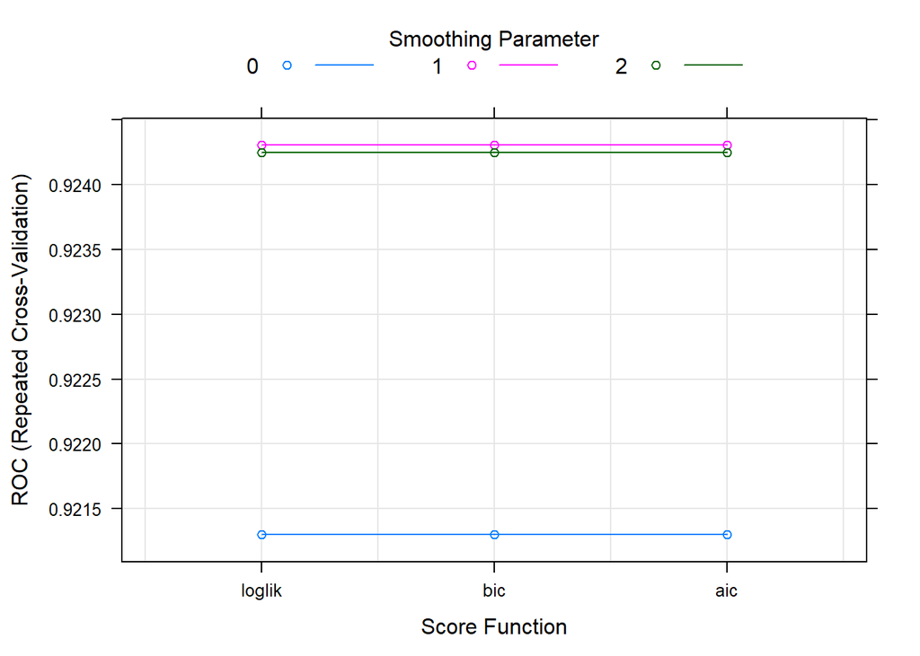

```
## [1] "Curva ROC:"
```

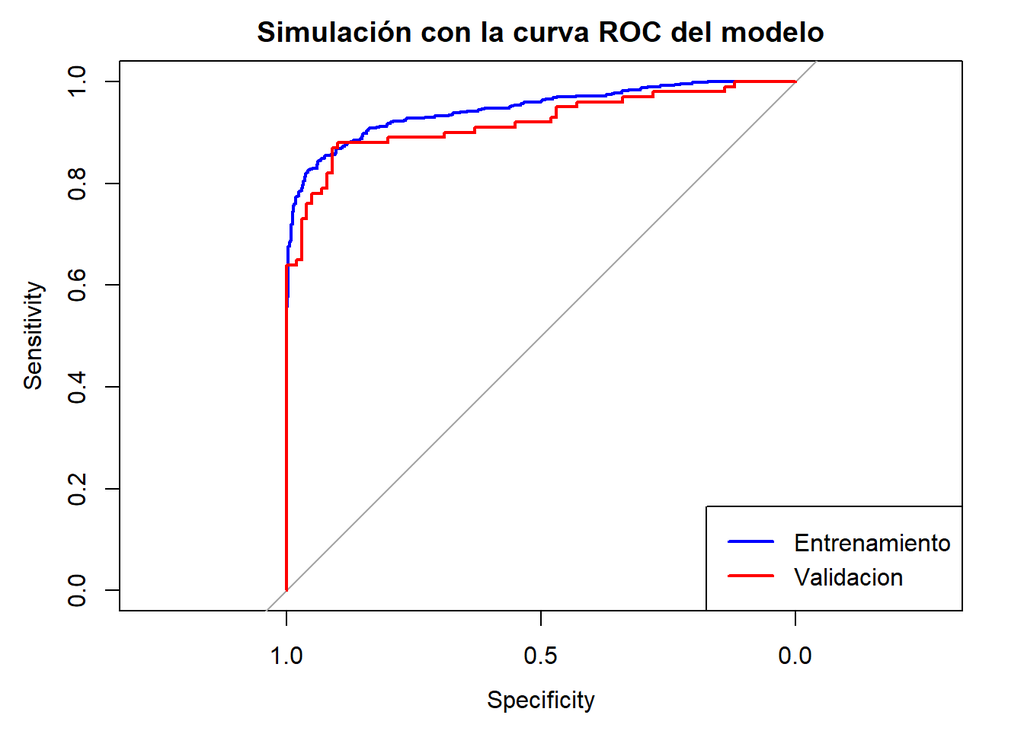

```r
plot_roc_curve(TAN.fit, data.training.d, data.testing.d)
```

## 3.2. Modelo Hill Climbing

```r
modeloTANHC <- list(label = "Hill Climbing Tree Augmented Naive Bayes Classifier",
                  library = "bnclassify",
                  type = "Classification",
                  parameters = data.frame( parameter = c("smooth"),
                                           class = c("numeric"),
                                           label = c("Smoothing Parameter")),
                  # Funciones
                  grid = function( x, y, len = NULL, search = "grid" ) {
                    if( search == "grid" ) {
                      out <- expand.grid(smooth = 0:( len - 1 ) )
                    } else {
                      out <- data.frame( smooth= runif( len, min = 0, max = 10 ),
                                         size = len,
                                         replace = TRUE )
                    }
                    out
                  },
                  loop = NULL,
                  fit = function( x, y, wts, param, lev, last, classProbs, ... ) {
                    dat <- if( is.data.frame( x ) ) x else as.data.frame( x )
                    bnclassify::bnc( 'tan_hc', 'y', x, 5, smooth = param$smooth )
                  },
                  predict = function( modelFit, newdata, submodels = NULL ) {
                    if( !is.data.frame( newdata ) ) newdata <- as.data.frame( newdata )
                    predict( modelFit, newdata )
                  },
                  prob = function( modelFit, newdata, submodels = NULL ) {
                    if( !is.data.frame( newdata ) ) newdata <- as.data.frame( newdata )
                    predict( modelFit, newdata, prob = TRUE )
                  },
                  levels = function( x ) x$obsLevels,
                  predictors = function( x, s = NULL, ... ) x$xNames,
                  tags = c( "Bayesian Model TAN HC", "Categorical Predictors Only" ),
                  sort = function( x ) x[ order( x[ , 1] ) , ] )
```

```r
#TANHC.fit <- train( data.training.d,
#                   data.training.d$y,
#                   method = modeloTANHC,
#                   metric = metrica,
#                   trControl = train.control )


#saveRDS(TANHC.fit, file = "TANHC.rds")

TANHC.fit <- readRDS(file = "TANHC.rds")

get_model_results(TANHC.fit, data.training.d, data.testing.d, TRUE, TRUE)
```

```
## [1] "Resultados para cada uno de los parámetros de la malla:"
## Hill Climbing Tree Augmented Naive Bayes Classifier
##
## 1000 samples
##    8 predictor
##    2 classes: 'No', 'Yes'
##
## No pre-processing
## Resampling: Cross-Validated (10 fold, repeated 5 times)
## Summary of sample sizes: 900, 900, 900, 900, 900, 900, ...
## Resampling results across tuning parameters:
##
##   smooth  ROC       Sens    Spec    Accuracy  Kappa
##   0       0.923372  0.9076  0.8144  0.8610    0.7220
##   1       0.923936  0.9000  0.8136  0.8568    0.7136
##   2       0.925216  0.9008  0.8152  0.8580    0.7160
##
## ROC was used to select the optimal model using the largest value.
## The final value used for the model was smooth = 2.
## [1] "#######################################################"
## [1] "Matriz de confusión del modelo:"
## [1] "#######################################################"
## Cross-Validated (10 fold, repeated 5 times) Confusion Matrix
##
## (entries are percentual average cell counts across resamples)
##
##           Reference
## Prediction   No  Yes
##        No  45.0  9.2
##        Yes  5.0 40.8
##
##  Accuracy (average) : 0.858
##
## [1] "#######################################################"
## [1] "Matriz de confusión comparando las predicciones del modelo y los datos de test:"
## [1] "#######################################################"
## Confusion Matrix and Statistics
##
##           Reference
## Prediction No Yes
```

[output cut: 22 more lines]

```
##
## [1] "#######################################################"
## [1] "Importancia de las variables:"
## ROC curve variable importance
##
##     Importance
## y      100.000
## V2      68.154
## V16     66.849
## V1      54.625
## V8      28.542
## V25      6.128
## V26      4.095
## V22      0.000
## [1] "Gráfico ROC-parámetros:"
```

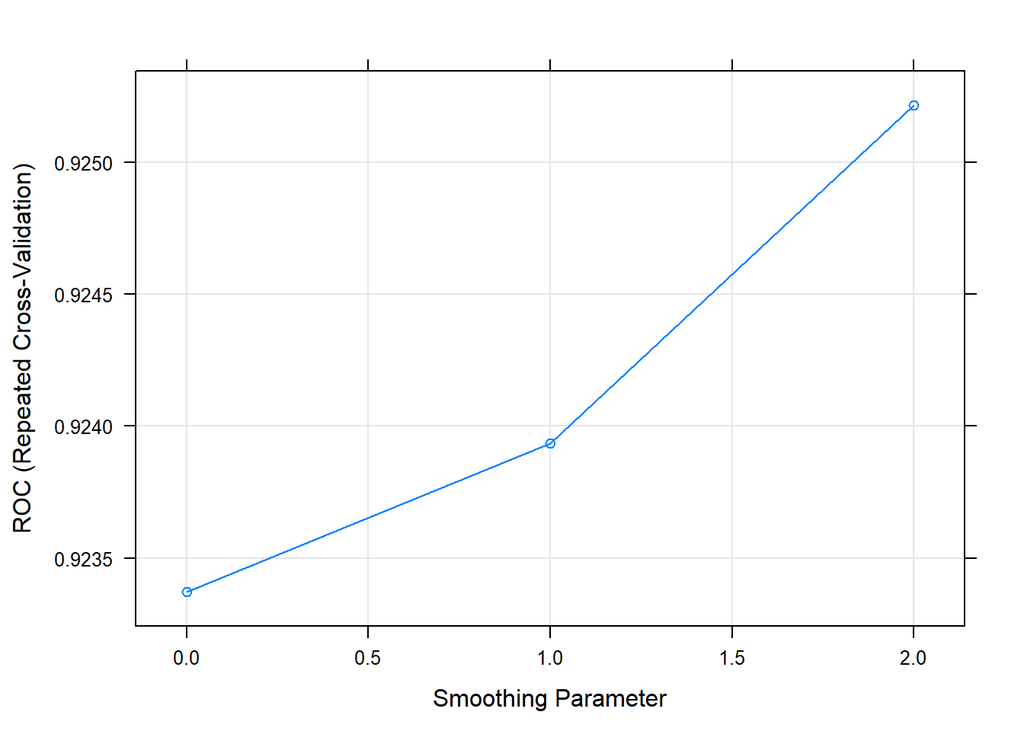

```
## [1] "Curva ROC:"
```

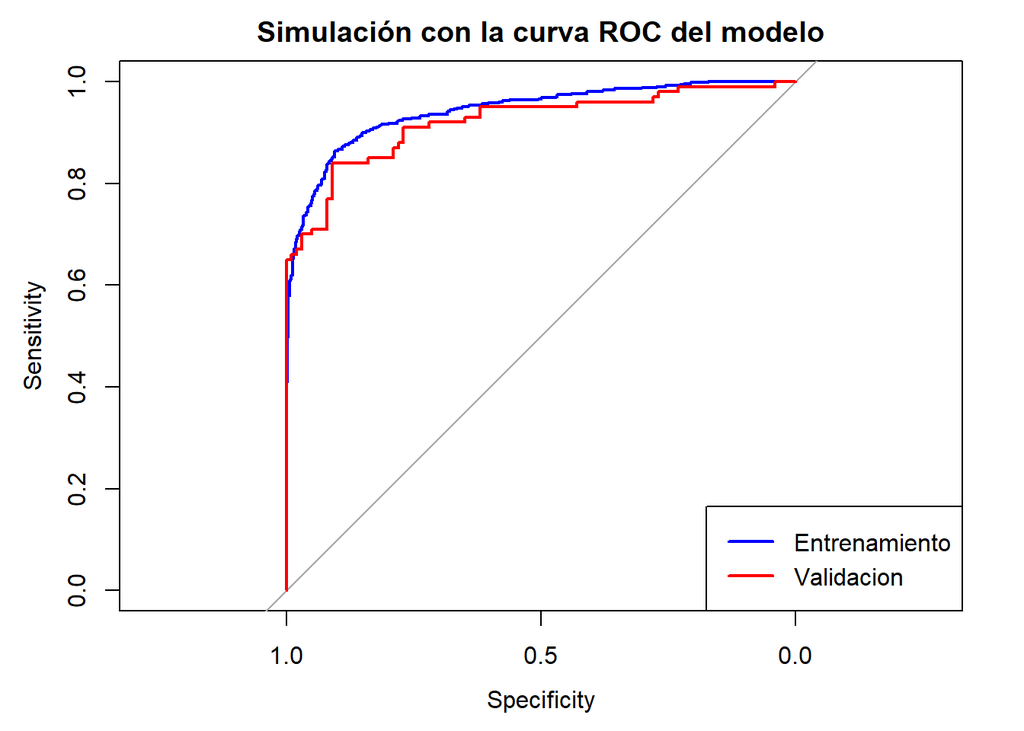

```r
plot_roc_curve(TANHC.fit, data.training.d, data.testing.d)
```

## 3.3. Modelo AODE

```r
modeloAODE <- list(label = "AODE Naive Bayes Classifier",
                            library = "bnclassify",
                            type = "Classification",
                            parameters = data.frame( parameter = c( "smooth" ),
                                                     class = c( "numeric" ),
                                                     label = c( "Smoothing Parameter" ) ),
                            grid = function( x, y, len = NULL, search = "grid" ) {
                              if( search == "grid" ) {
                                out <- expand.grid( smooth = 0:( len - 1 ) )
                              } else {
                                out <- data.frame( smooth = runif( len, min = 0, max = 10 ),
                                                   size = len,
                                                   replace = TRUE )
                              }
                              out
                            },
                            loop = NULL,
                            fit = function( x, y, wts, param, lev, last, classProbs, ... ) {
                              dat <- if( is.data.frame( x ) ) x else as.data.frame( x )
                              bnclassify::bnc( 'aode', 'y', x, smooth = param$smooth )
                            },
                            predict = function( modelFit, newdata, submodels = NULL ) {
                              if(!is.data.frame( newdata ) ) newdata <- as.data.frame( newdata )
                              predict( modelFit, newdata )
                            },
                            prob = function(modelFit, newdata, submodels = NULL) {
                              if(!is.data.frame(newdata)) newdata <- as.data.frame(newdata)
                              predict( modelFit, newdata, prob = TRUE )
                            },
                            levels = function( x ) x$obsLevels,
                            predictors = function( x, s = NULL, ... ) x$xNames,
                            tags = c( "Bayesian Model AODE", "Categorical Predictors Only"),
                            sort = function( x ) x[ order( x[ , 1] ), ] )
```

```r
# Entrenamiento
#AODE.fit <- train( data.training.d,
#                   data.training.d$y,
#                   method = modeloAODE,
#                   metric = metrica,
#                   trControl = train.control )

#saveRDS(AODE.fit, file = "AODE.rds")

AODE.fit <- readRDS(file = "AODE.rds")

get_model_results(AODE.fit, data.training.d, data.testing.d, TRUE, TRUE)
```

```
## [1] "Resultados para cada uno de los parámetros de la malla:"
## AODE Naive Bayes Classifier
##
## 1000 samples
##    8 predictor
##    2 classes: 'No', 'Yes'
##
## No pre-processing
## Resampling: Cross-Validated (10 fold, repeated 5 times)
## Summary of sample sizes: 900, 900, 900, 900, 900, 900, ...
## Resampling results across tuning parameters:
##
##   smooth  ROC       Sens   Spec    Accuracy  Kappa
##   0       0.935580  0.926  0.8288  0.8774    0.7548
##   1       0.935700  0.924  0.8264  0.8752    0.7504
##   2       0.935284  0.922  0.8236  0.8728    0.7456
##
## ROC was used to select the optimal model using the largest value.
## The final value used for the model was smooth = 1.
## [1] "#######################################################"
## [1] "Matriz de confusión del modelo:"
## [1] "#######################################################"
## Cross-Validated (10 fold, repeated 5 times) Confusion Matrix
##
## (entries are percentual average cell counts across resamples)
##
##           Reference
## Prediction   No  Yes
##        No  46.2  8.7
##        Yes  3.8 41.3
##
##  Accuracy (average) : 0.8752
##
## [1] "#######################################################"
## [1] "Matriz de confusión comparando las predicciones del modelo y los datos de test:"
## [1] "#######################################################"
## Confusion Matrix and Statistics
##
##           Reference
## Prediction No Yes
```

[output cut: 22 more lines]

```
##
## [1] "#######################################################"
## [1] "Importancia de las variables:"
## ROC curve variable importance
##
##     Importance
## y      100.000
## V2      70.198
## V16     67.057
## V1      55.076
## V8      30.130
## V26      9.379
## V22      4.494
## V25      0.000
## [1] "Gráfico ROC-parámetros:"
```

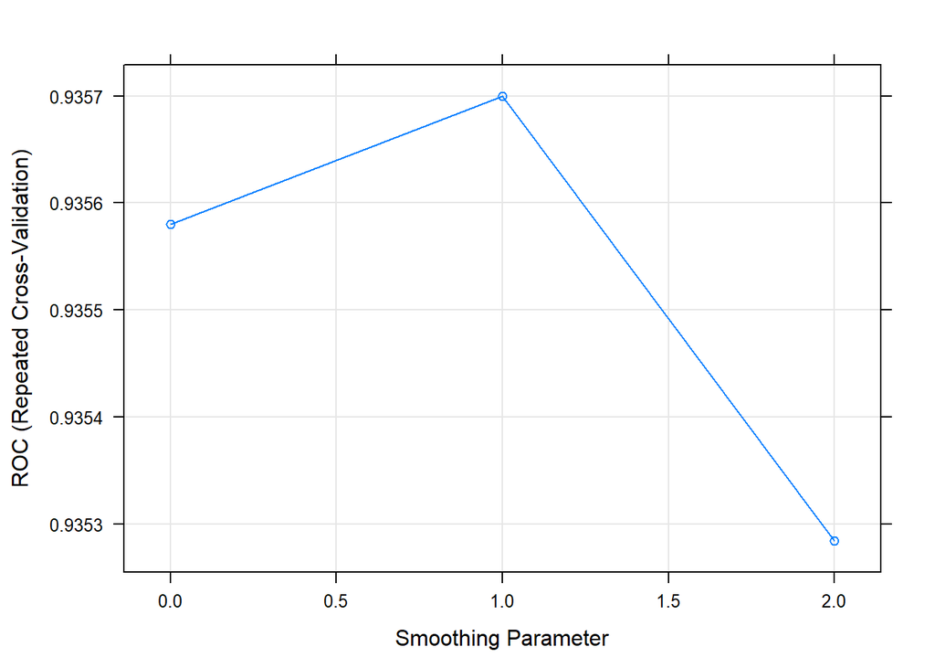

```
## [1] "Curva ROC:"
```

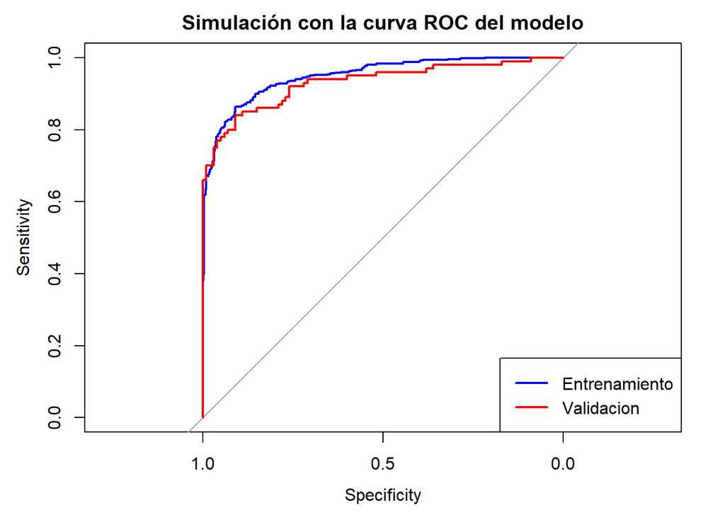

```r
plot_roc_curve(AODE.fit, data.training.d, data.testing.d)
```

## 3.4. Modelo de redes neuronales

```r
#set.seed(123)
#nnGrid <-  expand.grid(size = 1:30)
#clusterCPU <- registerDoParallel(cores=detectCores() - 1)
#nn.fit <- train(x = data.training[, names(data.training) != "y", with=FALSE],
#             y = data.training$y,
#             method = "mlp",
#             preProc = c("center", "scale"),
#             trControl = train.control,
#             metric = metrica
#             tuneGrid = nnGrid
#             )
#stopImplicitCluster()

#saveRDS(nn.fit, file = "nn.rds")

nn.fit <- readRDS(file = "nn.rds")

get_model_results(nn.fit, data.training, data.testing, TRUE, TRUE)
```

```
## [1] "Resultados para cada uno de los parámetros de la malla:"
## Multi-Layer Perceptron
##
## 1000 samples
##    7 predictor
##    2 classes: 'No', 'Yes'
##
## Pre-processing: centered (7), scaled (7)
## Resampling: Cross-Validated (10 fold, repeated 5 times)
## Summary of sample sizes: 900, 900, 900, 900, 900, 900, ...
## Resampling results across tuning parameters:
##
##   size  ROC       Sens    Spec    Accuracy  Kappa
##    1    0.880048  0.9756  0.7512  0.8634    0.7268
##    2    0.934016  0.9568  0.8508  0.9038    0.8076
##    3    0.938968  0.9444  0.8536  0.8990    0.7980
##    4    0.940280  0.9496  0.8532  0.9014    0.8028
##    5    0.940656  0.9444  0.8512  0.8978    0.7956
##    6    0.945032  0.9436  0.8528  0.8982    0.7964
##    7    0.948000  0.9452  0.8556  0.9004    0.8008
##    8    0.947984  0.9388  0.8588  0.8988    0.7976
##    9    0.947632  0.9388  0.8620  0.9004    0.8008
##   10    0.949336  0.9360  0.8612  0.8986    0.7972
##   11    0.951048  0.9424  0.8572  0.8998    0.7996
##   12    0.949736  0.9356  0.8564  0.8960    0.7920
##   13    0.950360  0.9392  0.8652  0.9022    0.8044
##   14    0.950664  0.9376  0.8600  0.8988    0.7976
##   15    0.950040  0.9368  0.8592  0.8980    0.7960
##   16    0.949176  0.9352  0.8588  0.8970    0.7940
##   17    0.951144  0.9408  0.8636  0.9022    0.8044
##   18    0.947216  0.9352  0.8592  0.8972    0.7944
##   19    0.949616  0.9348  0.8616  0.8982    0.7964
##   20    0.949664  0.9412  0.8584  0.8998    0.7996
##   21    0.950152  0.9352  0.8580  0.8966    0.7932
##   22    0.950912  0.9324  0.8656  0.8990    0.7980
##   23    0.947360  0.9316  0.8580  0.8948    0.7896
##   24    0.951000  0.9388  0.8620  0.9004    0.8008
##   25    0.948584  0.9364  0.8592  0.8978    0.7956
##   26    0.949680  0.9364  0.8620  0.8992    0.7984
##   27    0.948056  0.9384  0.8588  0.8986    0.7972
```

[output cut: 48 more lines]

```
##        'Positive' Class : No
##
## [1] "#######################################################"
## [1] "Importancia de las variables:"
## ROC curve variable importance
##
##     Importance
## V2     100.000
## V16     94.083
## V1      80.162
## V8      41.284
## V26     12.962
## V22      7.234
## V25      0.000
## [1] "Gráfico ROC-parámetros:"
```

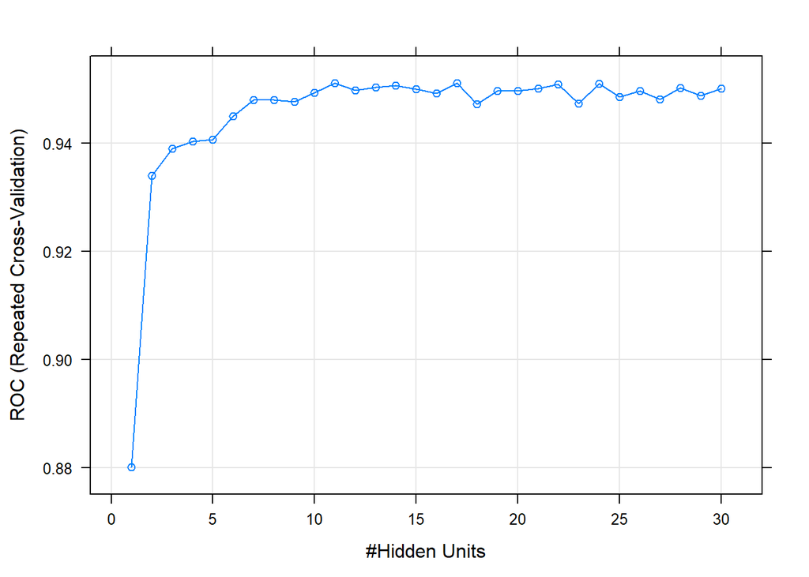

```
## [1] "Curva ROC:"
```

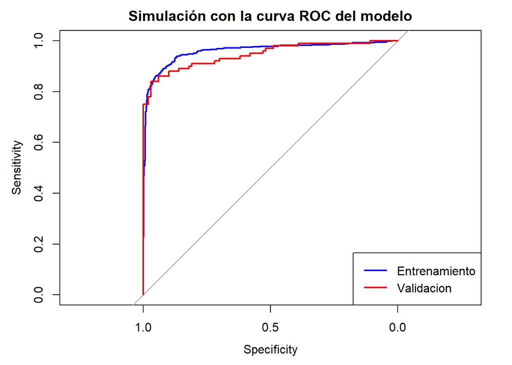

```r
plot_roc_curve(nn.fit, data.training, data.testing)
```

## 3.5. Modelo de k vecinos

```r
#set.seed(123)
#knnGrid <-  expand.grid(k  = 2:100)
#clusterCPU <- registerDoParallel(cores=detectCores() - 1)
#knn.fit <- train(y ~ . ,
#             data = data.training,
#             method = "knn",
#             preProc = c("center", "scale"),
#             trControl = train.control,
#             metric = metrica
#              tuneGrid = knnGrid
#             )
#stopImplicitCluster()

#saveRDS(knn.fit, file = "knn.rds")

knn.fit <- readRDS(file = "knn.rds")

get_model_results(knn.fit, data.training, data.testing, TRUE, TRUE)
```

```
## [1] "Resultados para cada uno de los parámetros de la malla:"
## k-Nearest Neighbors
##
## 1000 samples
##    7 predictor
##    2 classes: 'No', 'Yes'
##
## Pre-processing: centered (7), scaled (7)
## Resampling: Cross-Validated (10 fold, repeated 5 times)
## Summary of sample sizes: 900, 900, 900, 900, 900, 900, ...
## Resampling results across tuning parameters:
##
##   k    ROC       Sens    Spec    Accuracy  Kappa
##     2  0.928048  0.8708  0.8776  0.8742    0.7484
##     3  0.939284  0.9228  0.8708  0.8968    0.7936
##     4  0.944604  0.9264  0.8512  0.8888    0.7776
##     5  0.945760  0.9332  0.8548  0.8940    0.7880
##     6  0.947184  0.9364  0.8436  0.8900    0.7800
##     7  0.947908  0.9476  0.8340  0.8908    0.7816
##     8  0.946684  0.9480  0.8276  0.8878    0.7756
##     9  0.946488  0.9520  0.8196  0.8858    0.7716
##    10  0.944724  0.9504  0.8140  0.8822    0.7644
##    11  0.943896  0.9524  0.8088  0.8806    0.7612
##    12  0.943540  0.9532  0.8016  0.8774    0.7548
##    13  0.942996  0.9560  0.7964  0.8762    0.7524
##    14  0.942352  0.9560  0.7896  0.8728    0.7456
##    15  0.942016  0.9632  0.7856  0.8744    0.7488
##    16  0.942056  0.9664  0.7800  0.8732    0.7464
##    17  0.941852  0.9664  0.7808  0.8736    0.7472
##    18  0.941812  0.9684  0.7748  0.8716    0.7432
##    19  0.940512  0.9696  0.7756  0.8726    0.7452
##    20  0.940348  0.9716  0.7768  0.8742    0.7484
##    21  0.939816  0.9760  0.7748  0.8754    0.7508
##    22  0.939612  0.9760  0.7712  0.8736    0.7472
##    23  0.939544  0.9776  0.7688  0.8732    0.7464
##    24  0.939416  0.9784  0.7668  0.8726    0.7452
##    25  0.939336  0.9772  0.7640  0.8706    0.7412
##    26  0.938692  0.9780  0.7604  0.8692    0.7384
##    27  0.938644  0.9788  0.7596  0.8692    0.7384
##    28  0.938528  0.9788  0.7576  0.8682    0.7364
```

[output cut: 117 more lines]

```
##        'Positive' Class : No
##
## [1] "#######################################################"
## [1] "Importancia de las variables:"
## ROC curve variable importance
##
##     Importance
## V2     100.000
## V16     94.083
## V1      80.162
## V8      41.284
## V26     12.962
## V22      7.234
## V25      0.000
## [1] "Gráfico ROC-parámetros:"
```

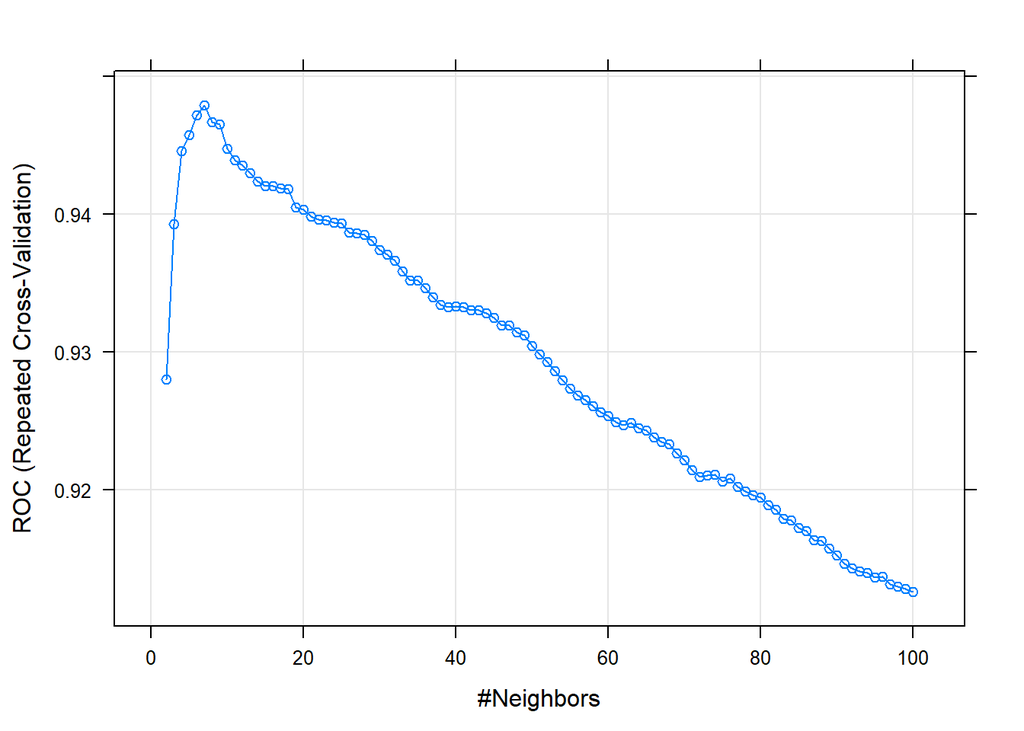

```
## [1] "Curva ROC:"
```

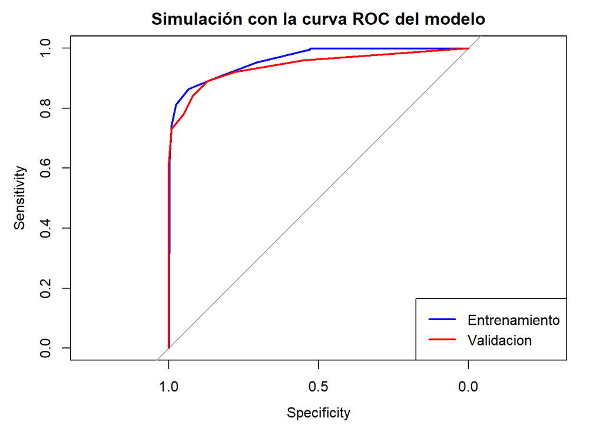

```r
plot_roc_curve(knn.fit, data.training, data.testing)
```

## 3.6. Modelo kernel k vecinos

```r
#set.seed(123)
#kknnGrid <- expand.grid(kmax = 1:20,
#                        distance = 1:15,
#                        kernel = c('gaussian')
#                        )
#
#clusterCPU <- registerDoParallel(cores=detectCores() - 1)
#kknn.fit <- train(y ~ . ,
#             data = data.training,
#             method = "kknn",
#             preProc = c("center", "scale"),
#             trControl = train.control,
#             metric = metrica
#              tuneGrid = kknnGrid
#             )
#stopImplicitCluster()

#saveRDS(kknn.fit, file = "kknn.rds")

kknn.fit <- readRDS(file = "kknn.rds")

get_model_results(kknn.fit, data.training, data.testing, TRUE, TRUE)
```

```
## [1] "Resultados para cada uno de los parámetros de la malla:"
## k-Nearest Neighbors
##
## 1000 samples
##    7 predictor
##    2 classes: 'No', 'Yes'
##
## Pre-processing: centered (7), scaled (7)
## Resampling: Cross-Validated (10 fold, repeated 5 times)
## Summary of sample sizes: 900, 900, 900, 900, 900, 900, ...
## Resampling results across tuning parameters:
##
##   kmax  distance  ROC       Sens    Spec    Accuracy  Kappa
##    1     1        0.894800  0.8964  0.8932  0.8948    0.7896
##    1     2        0.887600  0.8796  0.8956  0.8876    0.7752
```

[output cut: 360 more lines]

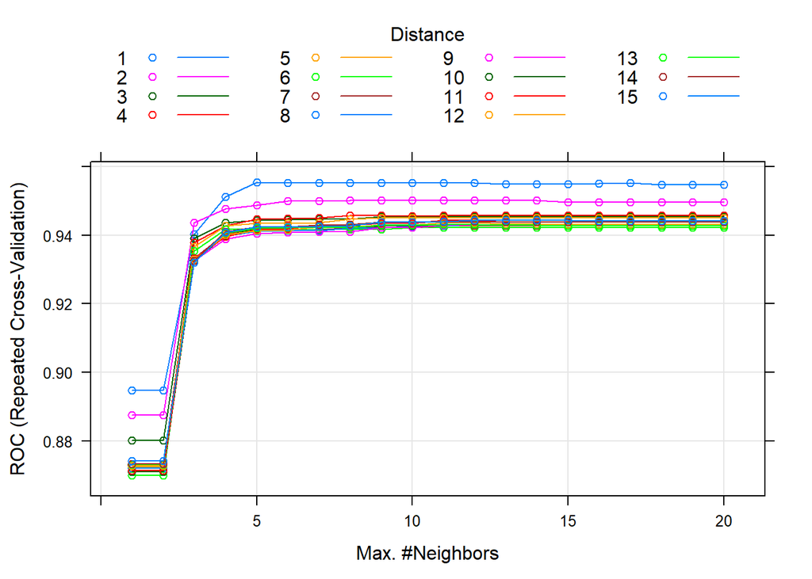

```
## [1] "Curva ROC:"
```

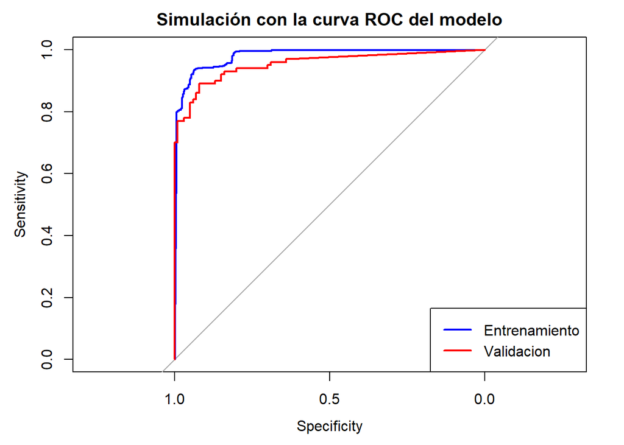

```r
plot_roc_curve(kknn.fit, data.training, data.testing)
```

## 3.7. Modelo de random forest

```r
#set.seed(123)
#RFGrid <-  expand.grid(mtry  = 1:30)
#clusterCPU <- registerDoParallel(cores=detectCores() - 1)
#rf.fit <- train(x = data.training[, names(data.training) != "y", with=FALSE],
#             y = data.training$y,
#             method = "parRF",
#             parms = list(split = "information"),
#             preProc = c("center", "scale"),
#             trControl = train.control,
#             metric = metrica,
#             tuneGrid = RFGrid
#             )
#stopImplicitCluster()

#saveRDS(rf.fit, file = "rf.rds")

rf.fit <- readRDS(file = "rf.rds")

get_model_results(rf.fit, data.training, data.testing, TRUE, TRUE)
```

```
## [1] "Resultados para cada uno de los parámetros de la malla:"
## Parallel Random Forest
##
## 1000 samples
##    7 predictor
##    2 classes: 'No', 'Yes'
##
## Pre-processing: centered (7), scaled (7)
## Resampling: Cross-Validated (10 fold, repeated 5 times)
## Summary of sample sizes: 900, 900, 900, 900, 900, 900, ...
## Resampling results across tuning parameters:
##
##   mtry  ROC       Sens    Spec    Accuracy  Kappa
##    1    0.961216  0.9512  0.8628  0.9070    0.8140
##    2    0.961464  0.9548  0.8668  0.9108    0.8216
##    3    0.960160  0.9468  0.8680  0.9074    0.8148
##    4    0.959332  0.9436  0.8692  0.9064    0.8128
##    5    0.958188  0.9372  0.8660  0.9016    0.8032
##    6    0.957424  0.9360  0.8672  0.9016    0.8032
##    7    0.956608  0.9344  0.8652  0.8998    0.7996
##    8    0.956644  0.9340  0.8684  0.9012    0.8024
##    9    0.956892  0.9312  0.8676  0.8994    0.7988
##   10    0.956792  0.9328  0.8676  0.9002    0.8004
##   11    0.956636  0.9348  0.8692  0.9020    0.8040
##   12    0.956408  0.9316  0.8696  0.9006    0.8012
##   13    0.956448  0.9320  0.8684  0.9002    0.8004
##   14    0.956412  0.9328  0.8664  0.8996    0.7992
##   15    0.956580  0.9332  0.8688  0.9010    0.8020
##   16    0.957200  0.9336  0.8676  0.9006    0.8012
##   17    0.956436  0.9328  0.8660  0.8994    0.7988
##   18    0.956840  0.9344  0.8676  0.9010    0.8020
##   19    0.956460  0.9332  0.8664  0.8998    0.7996
##   20    0.956764  0.9344  0.8676  0.9010    0.8020
##   21    0.957076  0.9332  0.8684  0.9008    0.8016
##   22    0.956640  0.9324  0.8664  0.8994    0.7988
##   23    0.956764  0.9340  0.8688  0.9014    0.8028
##   24    0.956800  0.9328  0.8680  0.9004    0.8008
##   25    0.956992  0.9328  0.8680  0.9004    0.8008
##   26    0.956776  0.9320  0.8672  0.8996    0.7992
##   27    0.956408  0.9328  0.8692  0.9010    0.8020
```

[output cut: 48 more lines]

```
##        'Positive' Class : No
##
## [1] "#######################################################"
## [1] "Importancia de las variables:"
## parRF variable importance
##
##     Overall
## V16 100.000
## V2   65.799
## V1   31.034
## V8   13.024
## V25   2.801
## V26   1.613
## V22   0.000
## [1] "Gráfico ROC-parámetros:"
```

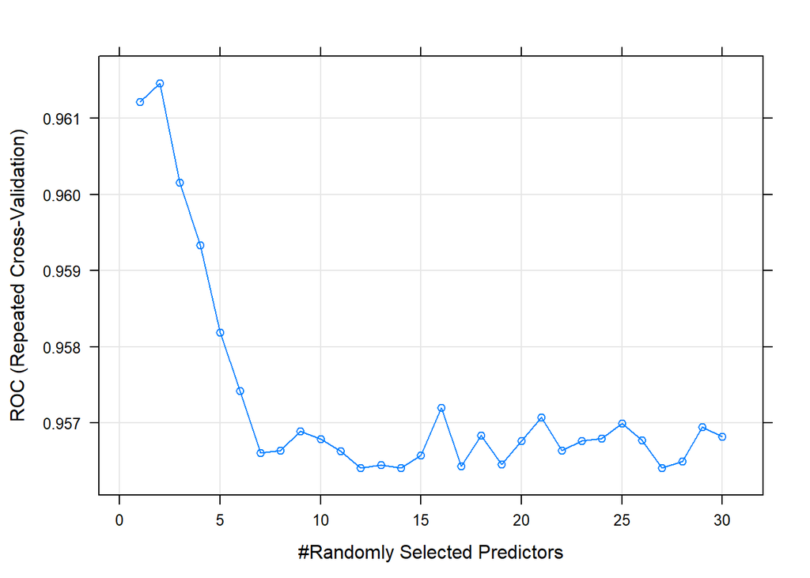

```
## [1] "Curva ROC:"
```

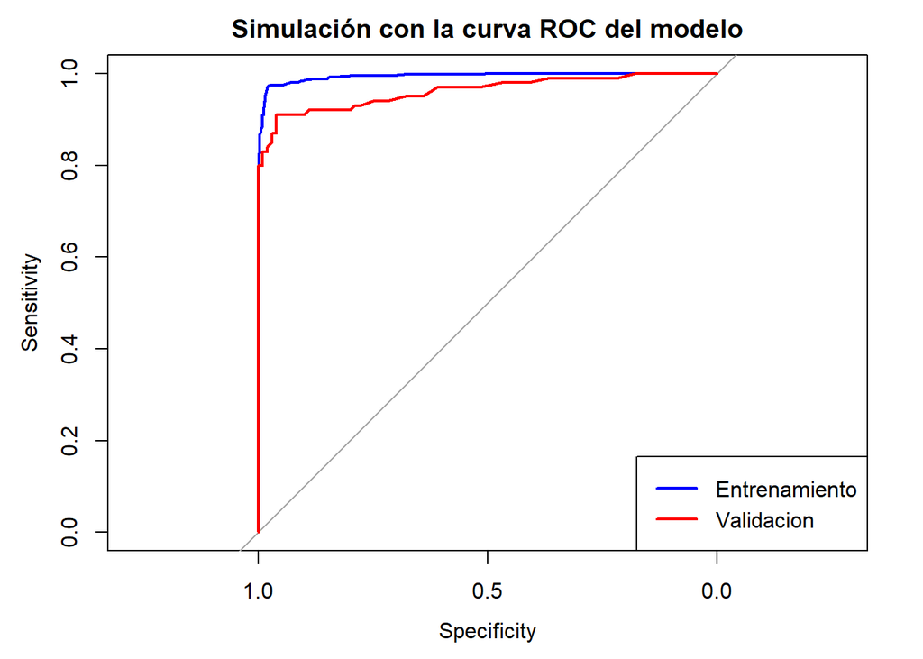

```r
plot_roc_curve(rf.fit, data.training, data.testing)
```

## 3.8. Modelo C5.0

```r
#set.seed(123)
#c5Grid <-  expand.grid(trials = 1:30,
#                        model = c("tree", "rules"),
#                        winnow = c(TRUE, FALSE))
#clusterCPU <- registerDoParallel(cores=detectCores() - 1)
#c5_0.fit <- train(y ~ . ,
#             data = data.training,
#             method = "C5.0",
#             parms = list(split = "information"),
#             preProc = c("center", "scale"),
#             trControl = train.control,
#             metric = metrica,
#              tuneGrid = c5Grid
#            )
#stopImplicitCluster()


#saveRDS(c5_0.fit, file = "c50.rds")

c5_0.fit <- readRDS(file = "c50.fit")

get_model_results(c5_0.fit, data.training, data.testing, TRUE, TRUE)
```

```
## [1] "Resultados para cada uno de los parámetros de la malla:"
## C5.0
##
## 1000 samples
##    7 predictor
##    2 classes: 'No', 'Yes'
##
## Pre-processing: centered (7), scaled (7)
## Resampling: Cross-Validated (10 fold, repeated 5 times)
## Summary of sample sizes: 900, 900, 900, 900, 900, 900, ...
## Resampling results across tuning parameters:
##
##   model  winnow  trials  ROC       Sens    Spec    Accuracy  Kappa
##   rules  FALSE    1      0.907956  0.9268  0.8484  0.8876    0.7752
##   rules  FALSE    2      0.925252  0.8696  0.8768  0.8732    0.7464
##   rules  FALSE    3      0.936660  0.9184  0.8592  0.8888    0.7776
##   rules  FALSE    4      0.942928  0.8996  0.8720  0.8858    0.7716
##   rules  FALSE    5      0.946440  0.9256  0.8636  0.8946    0.7892
##   rules  FALSE    6      0.947684  0.9176  0.8748  0.8962    0.7924
##   rules  FALSE    7      0.949892  0.9316  0.8664  0.8990    0.7980
##   rules  FALSE    8      0.950524  0.9244  0.8720  0.8982    0.7964
##   rules  FALSE    9      0.951284  0.9328  0.8660  0.8994    0.7988
##   rules  FALSE   10      0.952552  0.9268  0.8708  0.8988    0.7976
##   rules  FALSE   11      0.953500  0.9368  0.8692  0.9030    0.8060
##   rules  FALSE   12      0.953524  0.9304  0.8684  0.8994    0.7988
##   rules  FALSE   13      0.954240  0.9380  0.8672  0.9026    0.8052
##   rules  FALSE   14      0.955592  0.9372  0.8676  0.9024    0.8048
##   rules  FALSE   15      0.955576  0.9384  0.8652  0.9018    0.8036
##   rules  FALSE   16      0.954616  0.9376  0.8672  0.9024    0.8048
##   rules  FALSE   17      0.955100  0.9412  0.8668  0.9040    0.8080
##   rules  FALSE   18      0.954656  0.9420  0.8672  0.9046    0.8092
##   rules  FALSE   19      0.954752  0.9420  0.8656  0.9038    0.8076
##   rules  FALSE   20      0.954724  0.9400  0.8660  0.9030    0.8060
##   rules  FALSE   21      0.954916  0.9400  0.8648  0.9024    0.8048
##   rules  FALSE   22      0.955436  0.9444  0.8676  0.9060    0.8120
##   rules  FALSE   23      0.956292  0.9452  0.8668  0.9060    0.8120
##   rules  FALSE   24      0.956368  0.9452  0.8684  0.9068    0.8136
##   rules  FALSE   25      0.956272  0.9464  0.8688  0.9076    0.8152
##   rules  FALSE   26      0.956024  0.9480  0.8684  0.9082    0.8164
##   rules  FALSE   27      0.956072  0.9468  0.8696  0.9082    0.8164
```

[output cut: 139 more lines]

```
##        'Positive' Class : No
##
## [1] "#######################################################"
## [1] "Importancia de las variables:"
## C5.0 variable importance
##
##     Overall
## V16 100.000
## V8  100.000
## V2  100.000
## V26  28.387
## V1   28.065
## V25   7.419
## V22   0.000
## [1] "Gráfico ROC-parámetros:"
```

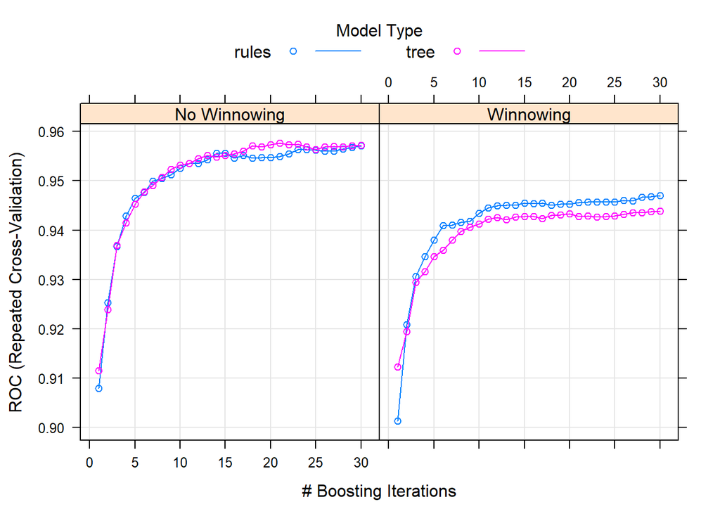

```
## [1] "Curva ROC:"
```

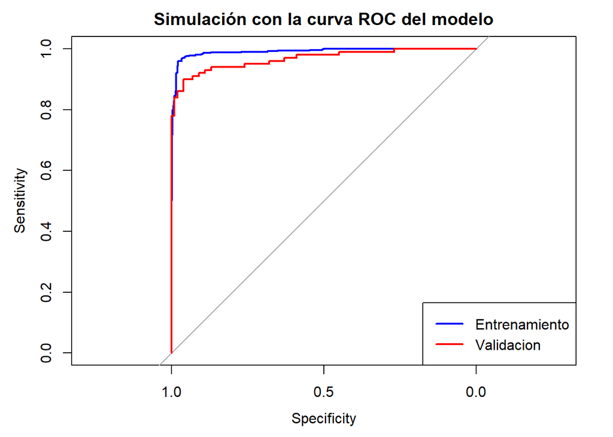

```r
plot_roc_curve(c5_0.fit, data.training, data.testing)
```

## 3.9. Model boosting

```r
#set.seed(123)
#boostGrid <-  expand.grid(nIter = 1:50, method = c("Adaboost.M1", "Real adaboost"))
#clusterCPU <- registerDoParallel(cores=detectCores() - 1)
#adaboost.fit <- train(x = data.training[, names(data.training) != "y", with=FALSE],
#             y = data.training$y,
#             method = "adaboost",
#             preProc = c("center", "scale"),
#             trControl = train.control,
#             metric = metrica,
#              tuneGrid = boostGrid
#             )
#stopImplicitCluster()


#saveRDS(adaboost.fit, file = "adaboost.rds")

adaboost.fit <- readRDS(file = "adaboost.rds")
get_model_results(adaboost.fit, data.training, data.testing, TRUE, TRUE)
```

```
## [1] "Resultados para cada uno de los parámetros de la malla:"
## AdaBoost Classification Trees
##
## 1000 samples
##    7 predictor
##    2 classes: 'No', 'Yes'
##
## Pre-processing: centered (7), scaled (7)
## Resampling: Cross-Validated (10 fold, repeated 5 times)
## Summary of sample sizes: 900, 900, 900, 900, 900, 900, ...
## Resampling results across tuning parameters:
##
##   nIter  method         ROC       Sens    Spec    Accuracy  Kappa
##    1     Adaboost.M1    0.874000  0.8896  0.8584  0.8740    0.7480
##    1     Real adaboost  0.582152  0.8896  0.8596  0.8746    0.7492
##    2     Adaboost.M1    0.921616  0.7456  0.9244  0.8350    0.6700
##    2     Real adaboost  0.725148  0.8908  0.8612  0.8760    0.7520
##    3     Adaboost.M1    0.933896  0.9020  0.8680  0.8850    0.7700
##    3     Real adaboost  0.801844  0.8808  0.8736  0.8772    0.7544
##    4     Adaboost.M1    0.942160  0.8400  0.9064  0.8732    0.7464
##    4     Real adaboost  0.834080  0.8860  0.8724  0.8792    0.7584
##    5     Adaboost.M1    0.946900  0.9100  0.8748  0.8924    0.7848
##    5     Real adaboost  0.841512  0.8920  0.8732  0.8826    0.7652
##    6     Adaboost.M1    0.948200  0.8724  0.9000  0.8862    0.7724
##    6     Real adaboost  0.849192  0.9000  0.8696  0.8848    0.7696
##    7     Adaboost.M1    0.950004  0.9172  0.8744  0.8958    0.7916
##    7     Real adaboost  0.850860  0.9084  0.8712  0.8898    0.7796
##    8     Adaboost.M1    0.951164  0.8944  0.8880  0.8912    0.7824
##    8     Real adaboost  0.850740  0.9136  0.8672  0.8904    0.7808
##    9     Adaboost.M1    0.953284  0.9264  0.8704  0.8984    0.7968
##    9     Real adaboost  0.855596  0.9172  0.8656  0.8914    0.7828
##   10     Adaboost.M1    0.954028  0.9108  0.8836  0.8972    0.7944
##   10     Real adaboost  0.854612  0.9184  0.8668  0.8926    0.7852
##   11     Adaboost.M1    0.954960  0.9260  0.8732  0.8996    0.7992
##   11     Real adaboost  0.853380  0.9232  0.8692  0.8962    0.7924
##   12     Adaboost.M1    0.955584  0.9204  0.8808  0.9006    0.8012
##   12     Real adaboost  0.852080  0.9232  0.8676  0.8954    0.7908
##   13     Adaboost.M1    0.956020  0.9252  0.8768  0.9010    0.8020
##   13     Real adaboost  0.850888  0.9304  0.8720  0.9012    0.8024
##   14     Adaboost.M1    0.956860  0.9236  0.8812  0.9024    0.8048
```

[output cut: 119 more lines]

```
##        'Positive' Class : No
##
## [1] "#######################################################"
## [1] "Importancia de las variables:"
## ROC curve variable importance
##
##     Importance
## V2     100.000
## V16     94.083
## V1      80.162
## V8      41.284
## V26     12.962
## V22      7.234
## V25      0.000
## [1] "Gráfico ROC-parámetros:"
```

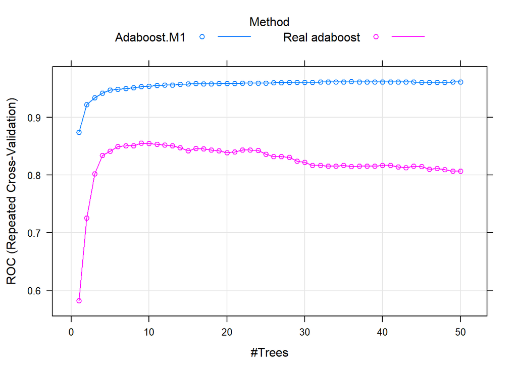

```
## [1] "Curva ROC:"
```

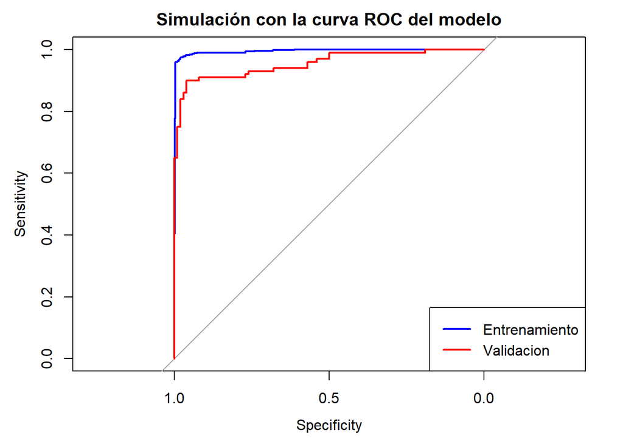

```r
plot_roc_curve(adaboost.fit, data.training, data.testing)
```